# Appendix

Kanav Malik

27 November,2020

**Libraries used**

```r
library(MASS)
library(knitr)
library(dplyr)
library(kableExtra)
```

# Appendix 1

Data size and actual coefficients

```r
rows <- 1000000 # number of data observations required
boot_samples <- 500 # number of times bootstrapping should be done
b0 <- 4 #slope
# coefficient
b1 <- 2
b2 <- 10
b3 <- 3
b4 <- 7
b5 <- 0.1
b6 <- 1
```

## Dataset 1

**Dataset** having no residuals and the response variable is linearly related to predictors i.e. conforms to all the assumptions of a linear regression model

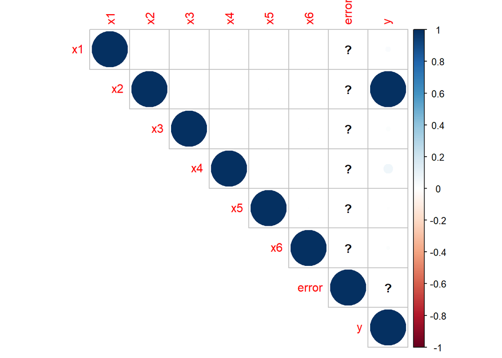

```r
# Create the data
set.seed(27049)
data_1 <- data.frame(x1=rnorm(rows,mean = 1,sd=0.5),x2=rbinom(rows,100,0.6),
                     x3=rexp(rows,rate=1/0.3),x4=rweibull(rows,shape = 2,scale = 1),
                     x5=rnorm(rows,mean=5,sd=2),x6=rpois(rows,lambda=0.3),error= 0)

data_1$y <- b0 + b1 * data_1$x1 + b2 * data_1$x2 + b3 * data_1$x3 + b4 * data_1$x4 +
            b5 * data_1$x5 + b6 * data_1$x6

# Create plots to check assumptions................................................
# Check multicollinearity through correlation plot
corrplot::corrplot(cor(data_1),type="upper")
```

## Dataset 2

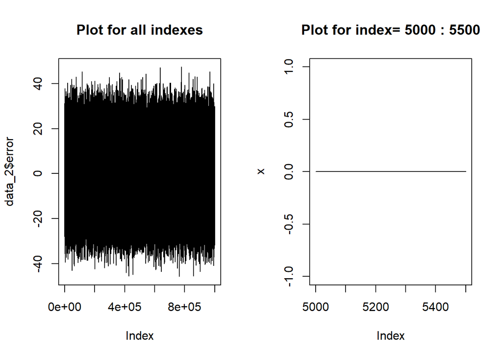

```r
# Create the data
set.seed(27049)
data_2 <- data.frame(x1=rnorm(rows,mean = 1,sd=0.5),x2=rbinom(rows,100,0.6),
                     x3=rexp(rows,rate=1/0.3),x4=rweibull(rows,shape = 2,scale = 1),
                     x5=rnorm(rows,mean=5,sd=2),x6=rpois(rows,lambda=0.3),
                     error=rnorm(rows,mean = 0,sd=10))

data_2$y <-
  b0 + b1 * data_2$x1 + b2 * data_2$x2 + b3 * data_2$x3 + b4 * data_2$x4 +
  b5 * data_2$x5 + b6 * data_2$x6 + data_2$error

## Check through scatterplot whether errors are random
par(mfrow=c(1,2)) # split screen in two half
plot(data_2$error, type="l",
     main = "Plot for all indexes")
plot(5000:5500, data_1$error[5000:5500], type="l", ylab="x",xlab = "Index",
     main=paste("Plot for index=",5000,":",5500))
```

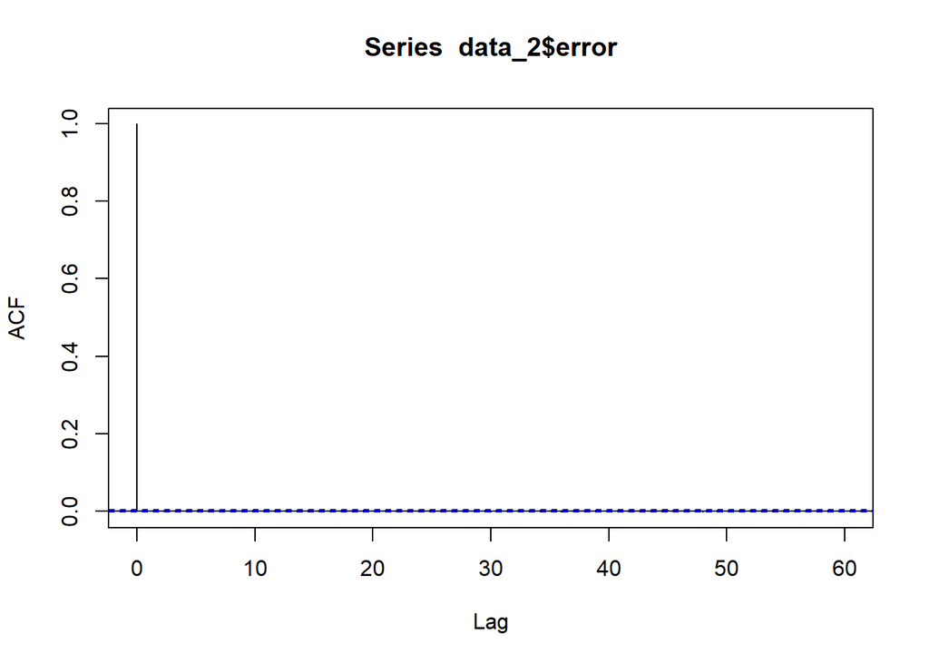

```r
# Create plots to check assumptions............................................
## Check through autocorrelation whether errors are independantly distributed
par(mfrow=c(1,1)) # one screen
acf(data_2$error) # autocorrelation plot
```

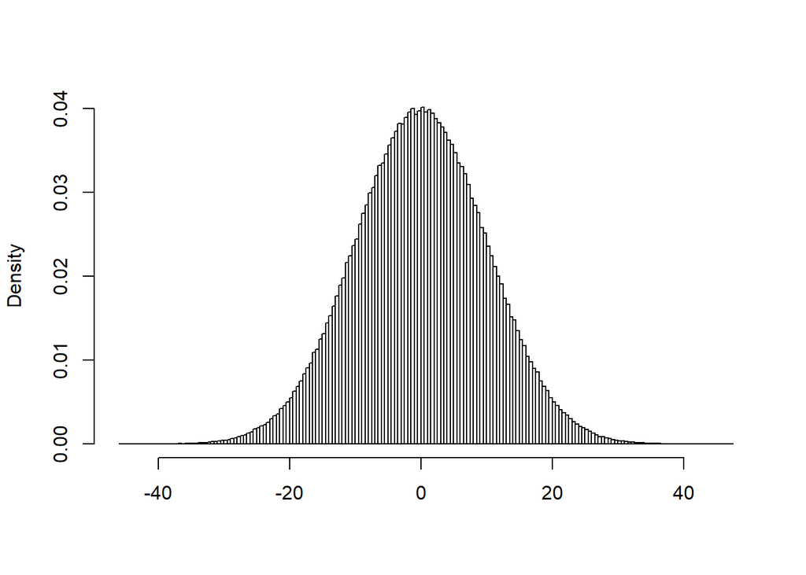

```r
## Check normality of error by doing visual inspection through histogram
hist(data_2$error, breaks="scott", main="", xlab="", freq=FALSE)
```

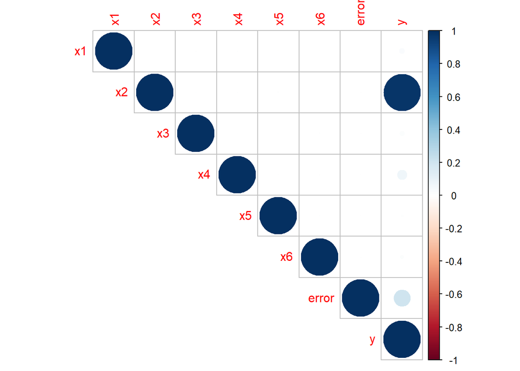

```r
## Check multicollinearity in data through correlation plot
corrplot::corrplot(cor(data_2),type="upper")
```

## Dataset 3

**Dataset** violates the assumption of linear relationship between independant variables and depandant variable.

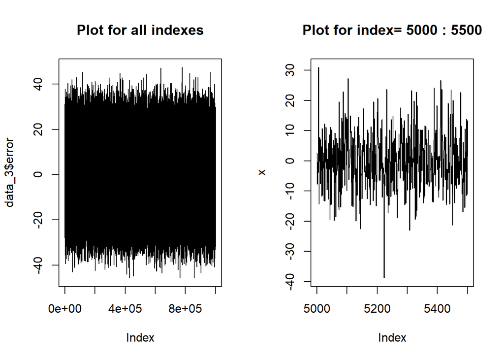

```r
# Create the data
set.seed(27049)
data_3 <- data.frame(x1=rnorm(rows,mean = 1,sd=0.5),x2=rbinom(rows,100,0.6),
                     x3=rexp(rows,rate=1/0.3),x4=rweibull(rows,shape = 2,scale = 1),
                     x5=rnorm(rows,mean=5,sd=2),x6=rpois(rows,lambda=1),
                     error=rnorm(rows,mean = 0,sd=10))

data_3$y <-
  b0 * data_3$x1^b1 * data_3$x2^b2 * data_3$x3^b3 * data_3$x4^b4 * data_3$x5 *
  data_3$x6^b6  + data_3$error

## Check through scatterplot whether errors are random
par(mfrow=c(1,2)) # split screen in two half
plot(data_3$error, type="l",
     main = "Plot for all indexes")
plot(5000:5500, data_3$error[5000:5500], type="l", ylab="x",xlab = "Index",
     main=paste("Plot for index=",5000,":",5500))
```

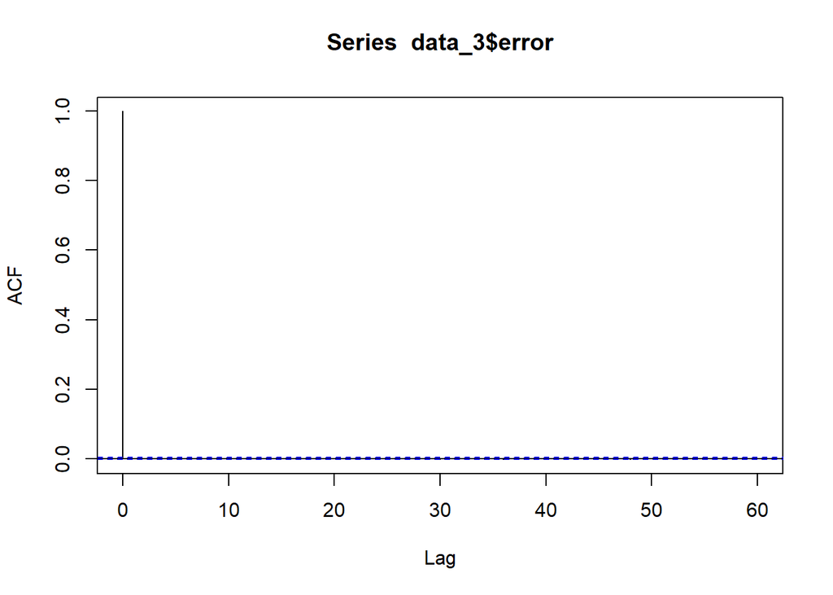

```r
## Check through autocorrelation whether errors are independantly distributed
par(mfrow=c(1,1)) # one screen
acf(data_3$error) # autocorrelation plot
```

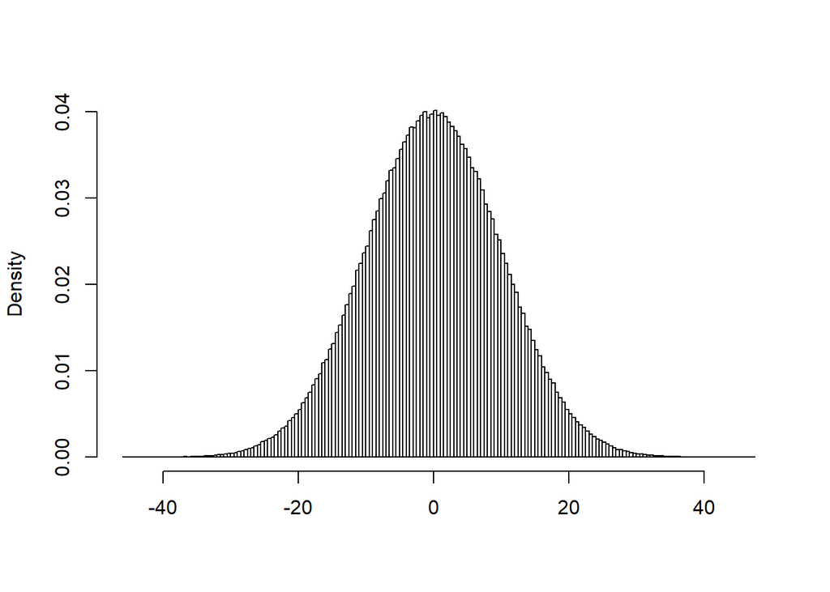

```r
## Check normality of error by doing visual inspection through histogram
hist(data_3$error, breaks="scott", main="", xlab="", freq=FALSE)
```

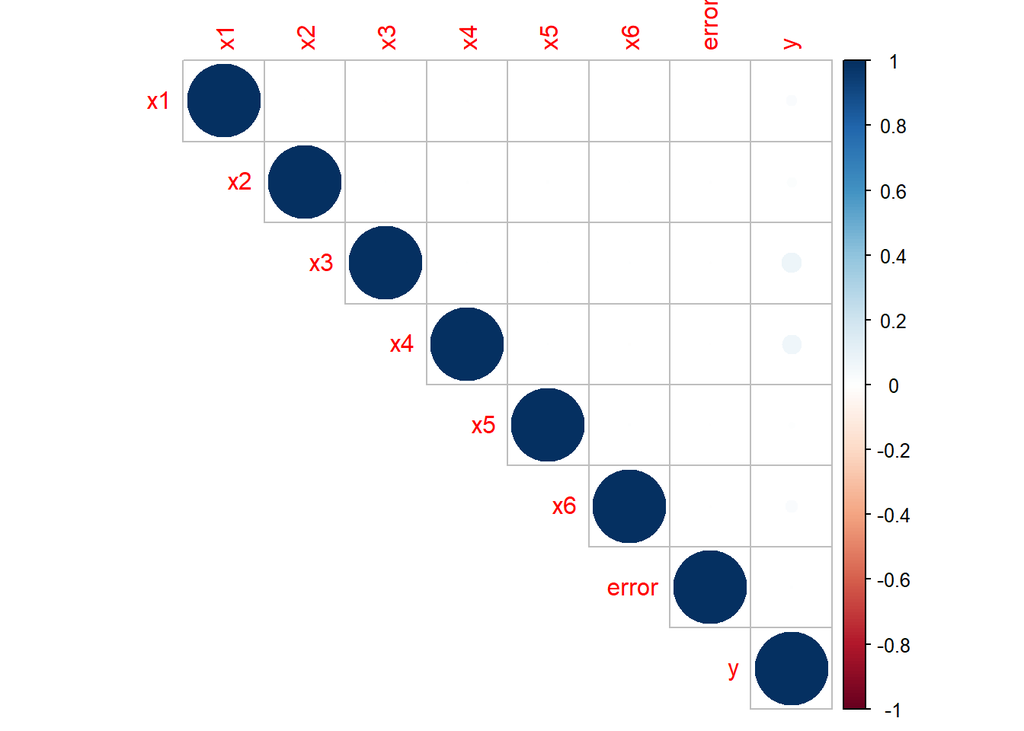

```r
## Check multicollinearity in data through correlation plot
corrplot::corrplot(cor(data_3),type="upper")
```

## Dataset 4

**Dataset** having residuals which are not independant and the response variable is linearly related to predictors i.e. violates the assumption of error being independant for linear regression model

```r
# Create the data
set.seed(27049)
data_4 <- data.frame(x1=rnorm(rows,mean = 1,sd=0.5),x2=rbinom(rows,100,0.6),
                     x3=rexp(rows,rate=1/0.3),x4=rweibull(rows,shape = 2,scale = 1),
                     x5=rnorm(rows,mean=5,sd=2),x6=rpois(rows,lambda=0.3))

## Get errors which are not independant and depends on the previous error.
## MCMC Metropolis-Hastings with gamma proposal

## Create a function for raleigh distribution which is our target distribution
fr <- function(x, y)
  {
    a <- 431 * (log(y) - log(x))
    b <- 437 * (log(1+x) - log(1+y))
    return(exp(a + b))
}

error <- numeric(rows)
error[1] <- rchisq(1, df=1) # intializing error_1 using chisquare with 1 df
k <- 0 # initializing counter for recording proposals rejected
y <- 0
xt <- 0
u <- runif(rows) # left hand side of choosing criteria

for (i in 2:rows)
  {
    xt  <- error[i-1]
    y   <- rgamma(1, shape=xt, rate=1)
    r   <- fr(xt, y) * dchisq(xt, df=y) / dchisq(y, df=xt)


     if (u[i] <= r) # condition is satisfied
       error[i] <- y # y accepted and added to chosen target distribution
     else {
       error[i] <- xt
       k    <- k+1 # y is rejected
     }
   }

print(k) # number of rejections
```

```
## [1] 72632
```

```r
paste("Proposals rejected =",(k/rows)*100,"%") # Rejection percentage
```

```
## [1] "Proposals rejected = 7.2632 %"
```

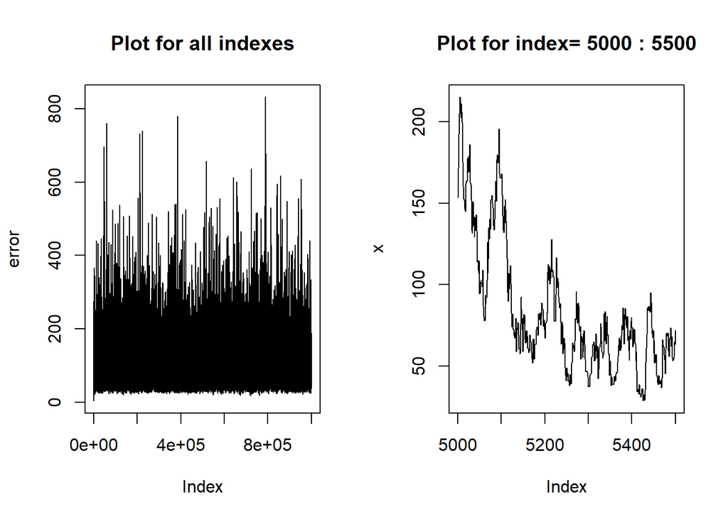

```r
data_4 <- cbind(data_4,error)

data_4$y <-
  b0 + b1 * data_4$x1 + b2 * data_4$x2 + b3 * data_4$x3 + b4 * data_4$x4 +
  b5 * data_4$x5 + b6 * data_4$x6 + data_4$error

# Create plots to check assumptions.............................................
## Check through scatterplot whether errors are random
par(mfrow=c(1,2)) # split screen in two half
plot(error, type="l",
     main = "Plot for all indexes") # plot the target distribution for error
plot(5000:5500, error[5000:5500], type="l", ylab="x",xlab = "Index",
     main=paste("Plot for index=",5000,":",5500))
```

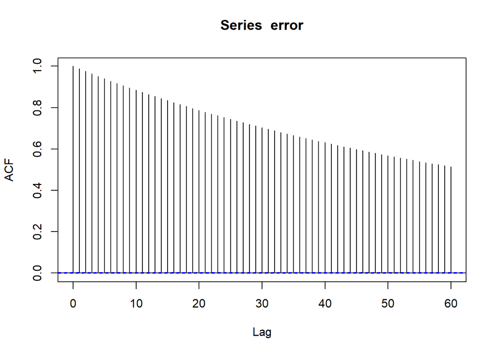

```r
## Check through autocorrelation whether errors are independantly distributed
par(mfrow=c(1,1)) # one screen
acf(error) # autocorrelation plot
```

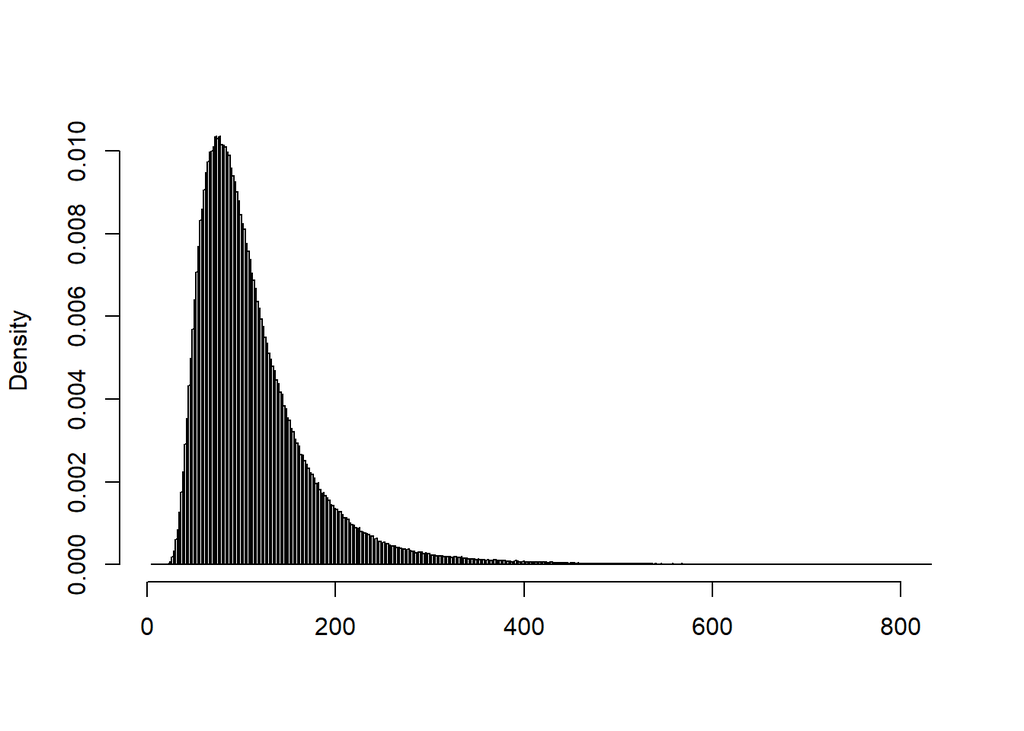

```r
## Check normality of error by doing visual inspection through histogram
hist(error, breaks="scott", main="", xlab="", freq=FALSE)
```

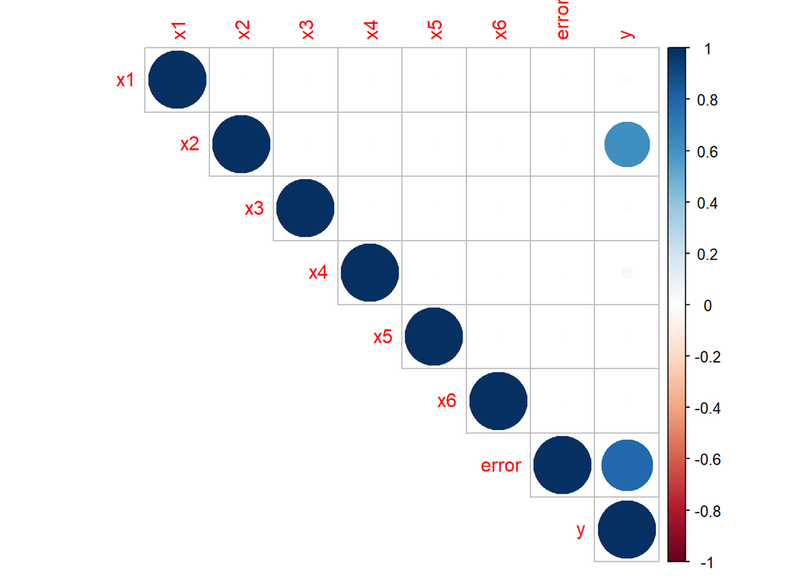

```r
## Check multicollinearity in data through correlation plot
corrplot::corrplot(cor(data_4),type="upper")
```

## Dataset 5

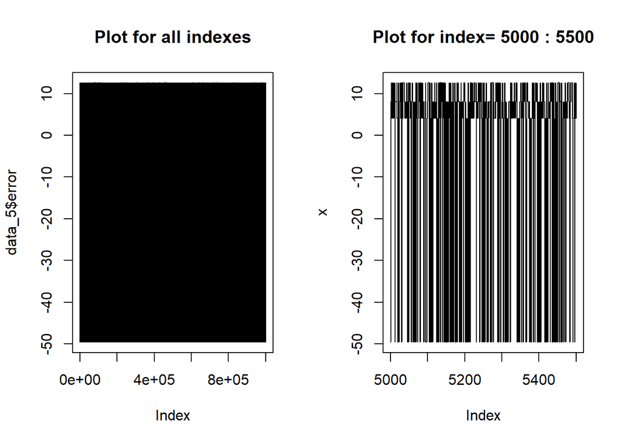

```r
# Create the data
set.seed(27049)
data_5 <- data.frame(x1=rnorm(rows,mean = 1,sd=0.5),x2=rbinom(rows,100,0.6),
                     x3=rexp(rows,rate=1/0.3),x4=rweibull(rows,shape = 2,scale = 1),
                     x5=rnorm(rows,mean=5,sd=2),x6=rpois(rows,lambda=0.3))

data_5$y <-
  b0 + b1 * data_5$x1 + b2 * data_5$x2 + b3 * data_5$x3 + b4 * data_5$x4 +
  b5 * data_5$x5 + b6 * data_5$x6

data_5$error <- ifelse(data_5$y<quantile(data_5$y,0.25),rnorm(1,0,5),
                       ifelse(data_5$y<quantile(data_5$y,0.5),rnorm(1,0,10),
                       ifelse(data_5$y<quantile(data_5$y,0.75),rnorm(1,0,15),
                              rnorm(1,0,20))))

data_5$y <-
  b0 + b1 * data_5$x1 + b2 * data_5$x2 + b3 * data_5$x3 + b4 * data_5$x4 +
  b5 * data_5$x5 + b6 * data_5$x6 + data_5$error

# Create plots to check assumptions..........................................
## Check through scatterplot whether errors are random
par(mfrow=c(1,2)) # split screen in two half
plot(data_5$error, type="l",
     main = "Plot for all indexes")
plot(5000:5500, data_5$error[5000:5500], type="l", ylab="x",xlab = "Index",
     main=paste("Plot for index=",5000,":",5500))
```

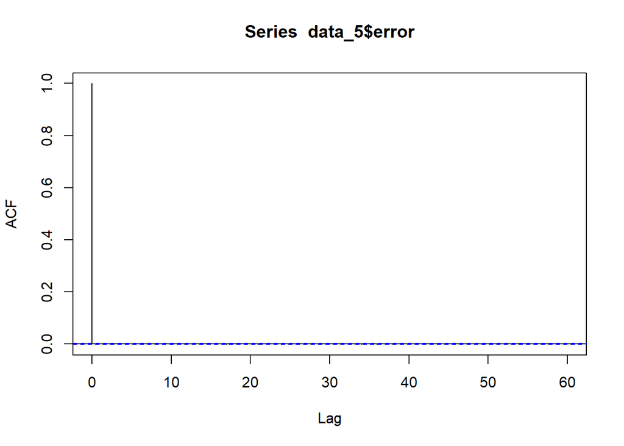

```r
## Check through autocorrelation whether errors are independantly distributed
par(mfrow=c(1,1)) # one screen
acf(data_5$error) # autocorrelation plot
```

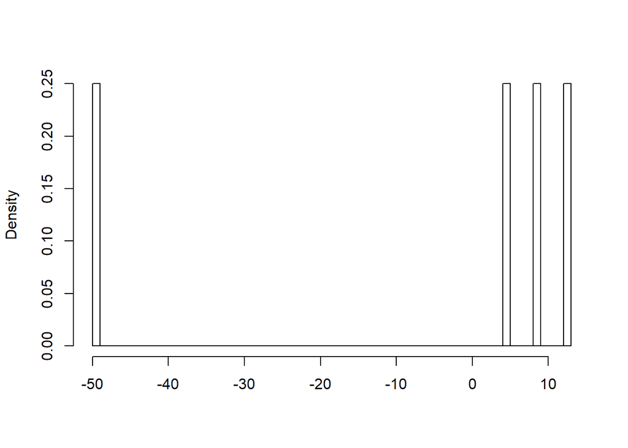

```r
## Check normality of error by doing visual inspection through histogram
hist(data_5$error, breaks="scott", main="", xlab="", freq=FALSE)
```

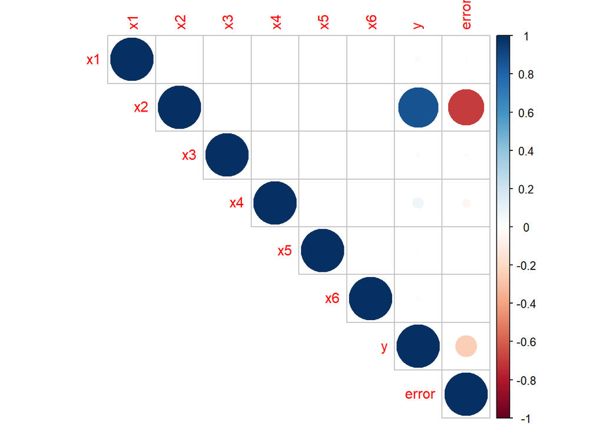

```r
## Check multicollinearity in data through correlation plot
corrplot::corrplot(cor(data_5),type="upper")
```

## Dataset 6

**Dataset** having x4,x5,x6 highly correlated within themselves and with the error i.e. violates the assumption of no multicollinearity

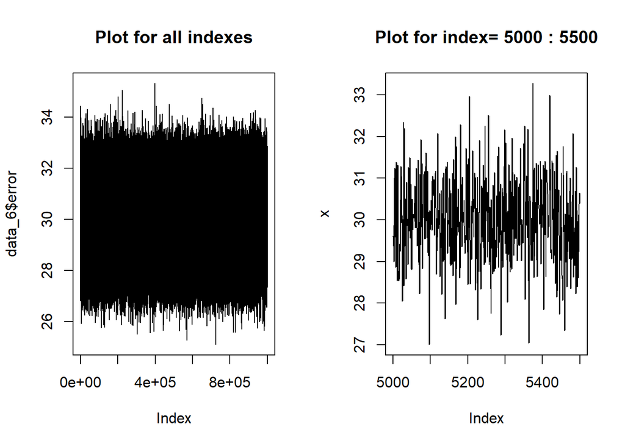

```r
# Create the data
set.seed(27049)
data_6 <- data.frame(x1=rnorm(rows,mean = 1,sd=0.5),x2=rbinom(rows,100,0.6),
                     x3=rpois(rows,0.3))

mu          <- c(50,60,70,30)  # Column means
Sigma       <- matrix(c(1,0.98,0.98,0.98,0.98,1,0.98,0.98,0.98,0.98,
                        1,0.98,0.98,0.98,0.98,1),
                      nrow = 4,ncol = 4,byrow = T) # Covariance matrix

## using mvrnorm from library(MASS) to generate multivariate normal numbers
mat <- data.frame(mvrnorm(rows, mu, Sigma))
colnames(mat) <- c("x4","x5","x6","error")
data_6 <- cbind(data_6,mat)

data_6$y <-
  b0 + b1 * data_6$x1 + b2 * data_6$x2 + b3 * data_6$x3 + b4 * data_6$x4 +
  b5 * data_6$x5 + b6 * data_6$x6 + data_6$error

# Create plots to check assumptions...........................................
## Check through scatterplot whether errors are random
par(mfrow=c(1,2)) ## split screen in two half
plot(data_6$error, type="l",
     main = "Plot for all indexes")
plot(5000:5500, data_6$error[5000:5500], type="l", ylab="x",xlab = "Index",
     main=paste("Plot for index=",5000,":",5500))
```

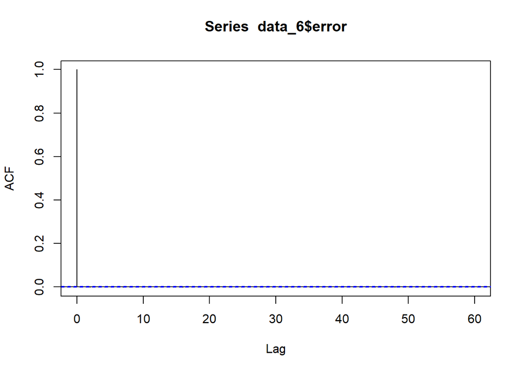

```r
## Check through autocorrelation whether errors are independantly distributed
par(mfrow=c(1,1)) ## one screen
acf(data_6$error) ## autocorrelation plot
```

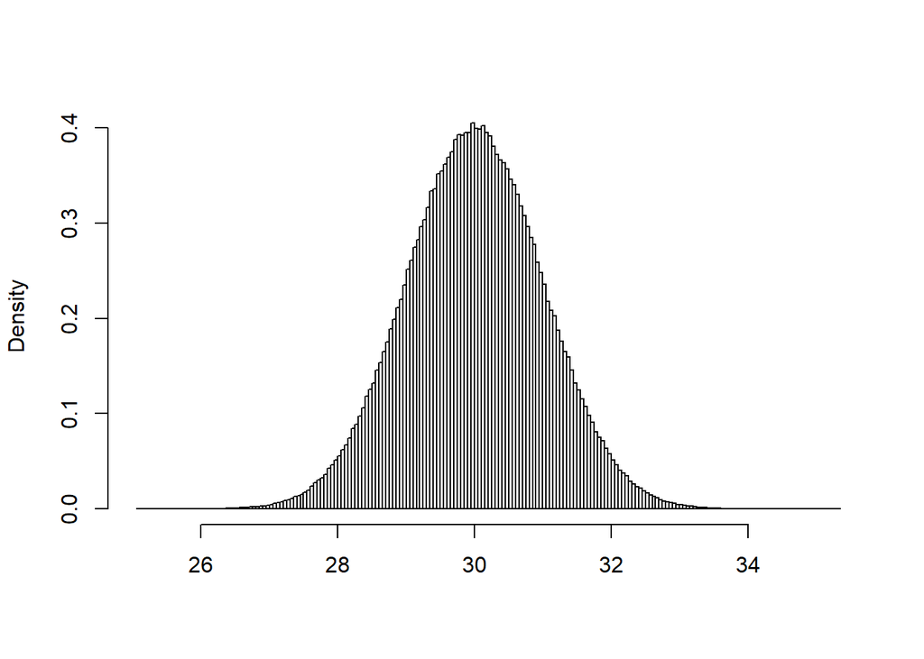

```r
## Check normality of error by doing visual inspection through histogram
hist(data_6$error, breaks="scott", main="", xlab="", freq=FALSE)
```

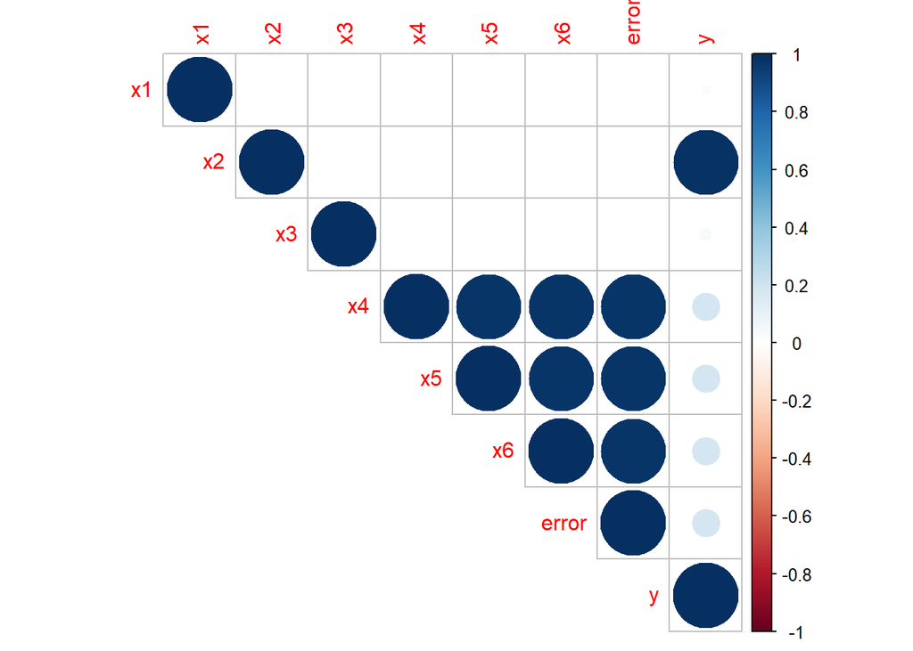

```r
## Check multicollinearity in data through correlation plot
corrplot::corrplot(cor(data_6),type="upper")
```

## Dataset 7

**Dataset** violates the assumption of normality of residuals

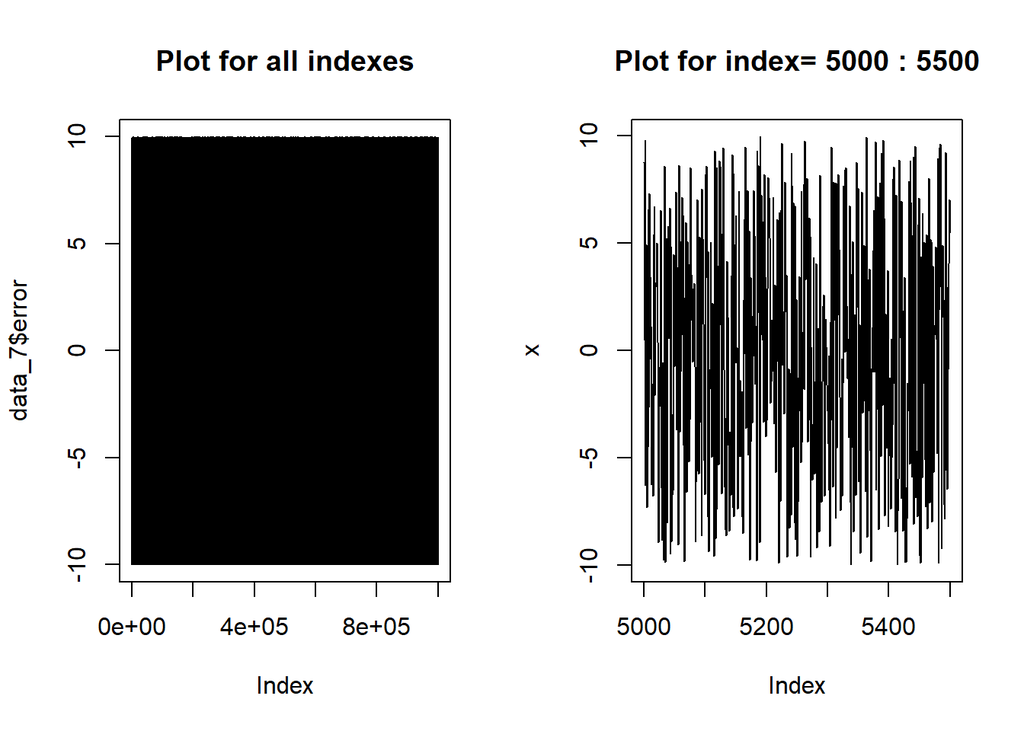

```r
# Create the data
set.seed(27049)
data_7 <- data.frame(x1=rnorm(rows,mean = 1,sd=0.5),x2=rbinom(rows,100,0.6),
                     x3=rexp(rows,rate=1/0.3),x4=rweibull(rows,shape = 2,scale = 1),
                     x5=rnorm(rows,mean=5,sd=2),x6=rpois(rows,lambda=0.3),
                     error=runif(rows,min=-10,max=10))

data_7$y <-
  b0 + b1 * data_7$x1^2 + b2 * data_7$x2^2 + b3 * data_7$x3^2 + b4 * data_7$x4^2 +
  b5 * data_7$x5 + b6 * data_7$x6 + data_7$error

# Create plots to check assumptions...............................................
## Check through scatterplot whether errors are random
par(mfrow=c(1,2)) ## split screen in two half
plot(data_7$error, type="l",
     main = "Plot for all indexes")
plot(5000:5500, data_7$error[5000:5500], type="l", ylab="x",xlab = "Index",
     main=paste("Plot for index=",5000,":",5500))
```

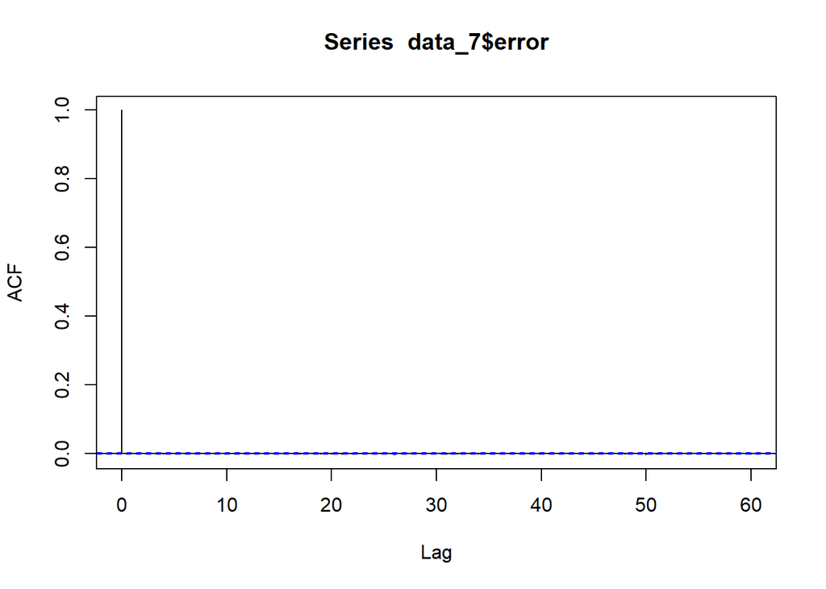

```r
## Check through autocorrelation whether errors are independantly distributed
par(mfrow=c(1,1)) ## one screen
acf(data_7$error) ## autocorrelation plot
```

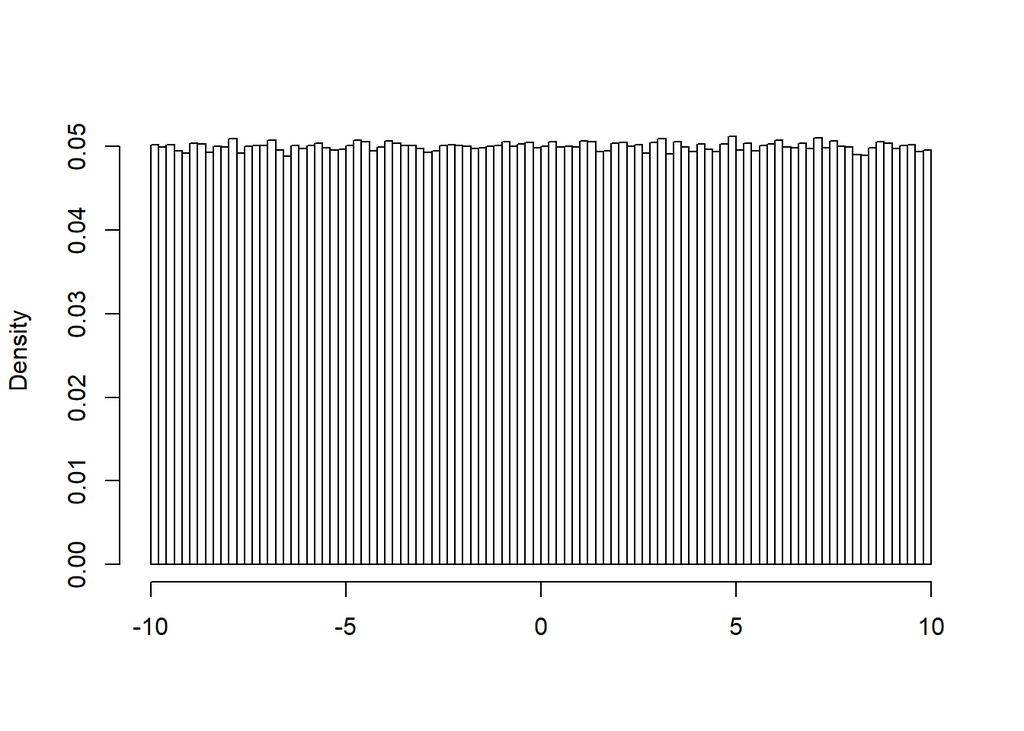

```r
## Check normality of error by doing visual inspection through histogram
hist(data_7$error, breaks="scott", main="", xlab="", freq=FALSE)
```

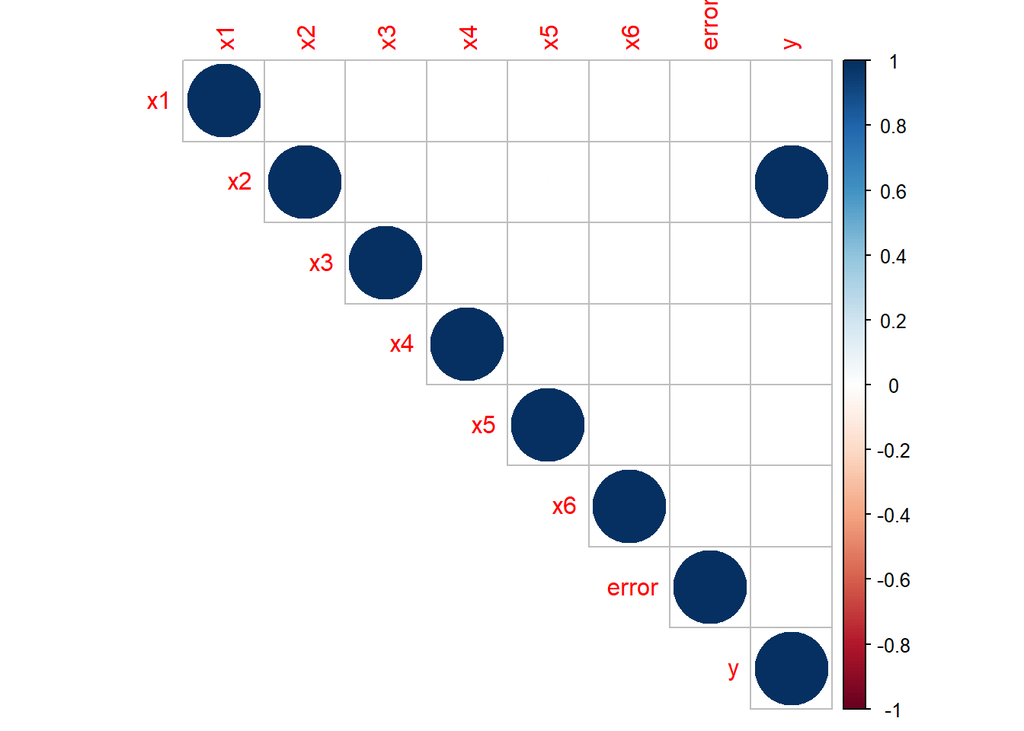

```r
## Check multicollinearity in data through correlation plot
corrplot::corrplot(cor(data_7),type="upper")
```

## Dataset 8

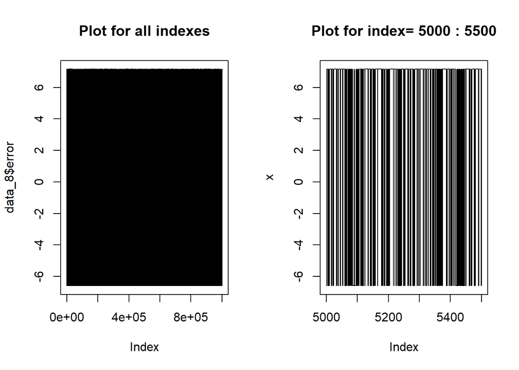

```r
# Create the data
set.seed(27049 )
data_8 <- data.frame(x1=rnorm(rows,mean = 1,sd=0.5),x2=rbinom(rows,100,0.6),
                     x3=rpois(rows,0.3))

mu          <- c(50,60,70) ##Column means
## Covariance matrix
Sigma       <- matrix(c(1,0.8,0.8,0.8,1,0.8,0.8,0.8,1),nrow = 3,ncol = 3,byrow = T)

## using mvrnorm from library(MASS) to generate multivariate normal numbers
mat <- data.frame(mvrnorm(rows, mu, Sigma))
colnames(mat) <- c("x4","x5","x6")
data_8 <- cbind(data_8,mat)

data_8$y <-
  b0 * data_8$x1^b1 * data_8$x2^b2 * data_8$x3^b3 * data_8$x4^b4 * data_8$x5^b5 *
  data_8$x6^b6

data_8$error <- ifelse(data_8$y<quantile(data_8$y,0.25),rnorm(1,5,5),
                ifelse(data_8$y<quantile(data_8$y,0.5),rnorm(1,10,10),
                ifelse(data_8$y<quantile(data_8$y,0.75),rnorm(1,15,15),
                       rnorm(1,20,20))))

data_8$y <-
  b0 * data_8$x1^b1 * data_8$x2^b2 * data_8$x3^b3 * data_8$x4^b4 * data_8$x5^b5 *
  data_8$x6^b6 + data_8$error

# Create plots to check assumptions...........................................
## Check through scatterplot whether errors are random
par(mfrow=c(1,2)) ##split screen in two half
plot(data_8$error, type="l",
     main = "Plot for all indexes")
plot(5000:5500, data_8$error[5000:5500], type="l", ylab="x",xlab = "Index",
     main=paste("Plot for index=",5000,":",5500))
```

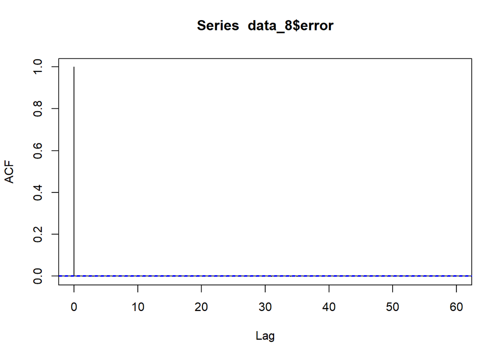

```r
## Check through autocorrelation whether errors are independantly distributed
par(mfrow=c(1,1)) ##one screen
acf(data_8$error) ##autocorrelation plot
```

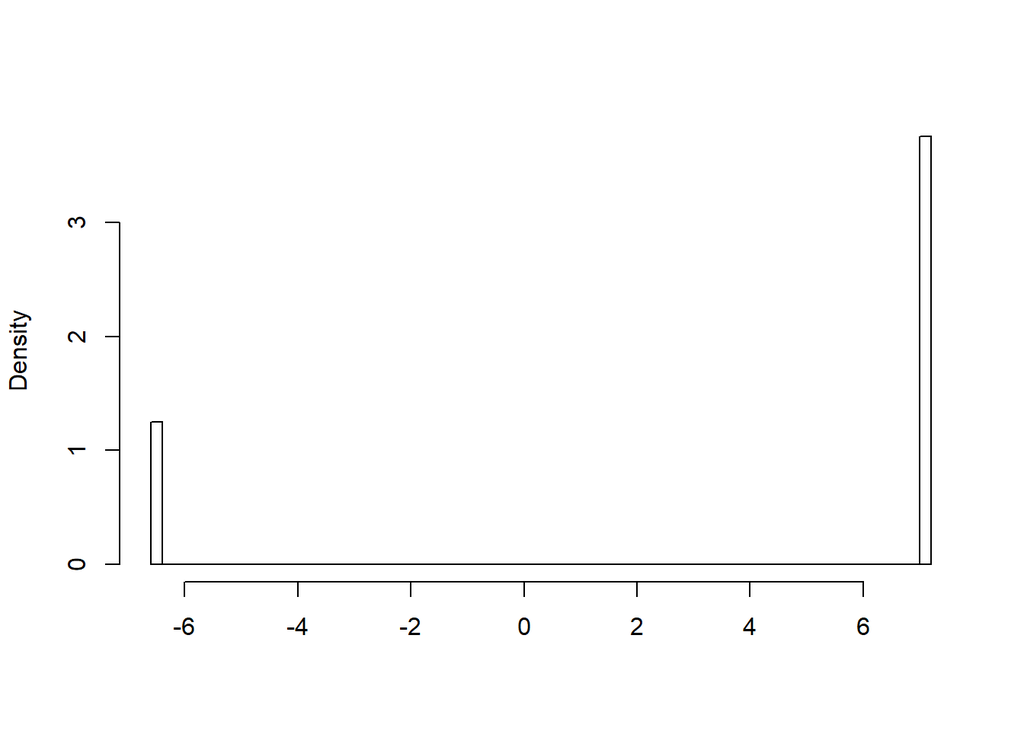

```r
## Check normality of error by doing visual inspection through histogram
hist(data_8$error, breaks="scott", main="", xlab="", freq=FALSE)
```

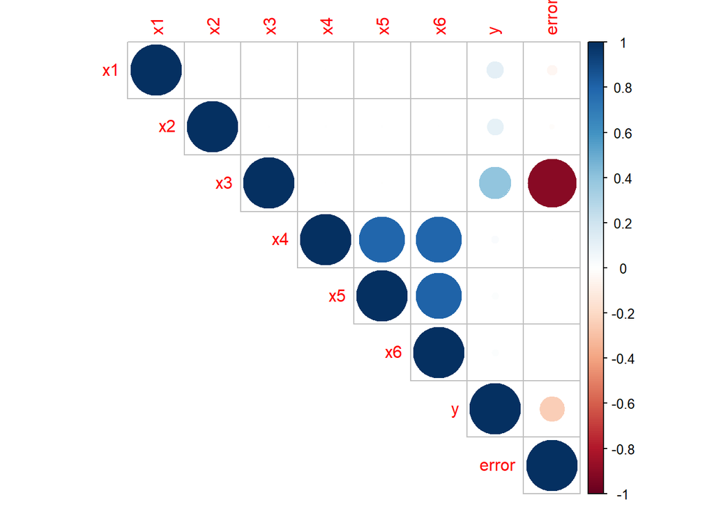

```r
## Check multicollinearity in data through correlation plot
corrplot::corrplot(cor(data_8),type="upper")
```

# Appendix 2

**Train/Test splits for each dataset**

```r
# Sample indexes of train set
train_index <-sample(rows,size = rows*0.80,replace = FALSE)

# Train datasets
TrainData_1 <- data_1[train_index,]
TrainData_2 <- data_2[train_index,]
TrainData_3 <- data_3[train_index,]
TrainData_4 <- data_4[train_index,]
TrainData_5 <- data_5[train_index,]
TrainData_6 <- data_6[train_index,]
TrainData_7 <- data_7[train_index,]
TrainData_8 <- data_8[train_index,]

#Train datasets
TestData_1 <- data_1[-train_index,]
TestData_2 <- data_2[-train_index,]
TestData_3 <- data_3[-train_index,]
TestData_4 <- data_4[-train_index,]
TestData_5 <- data_5[-train_index,]
TestData_6 <- data_6[-train_index,]
TestData_7 <- data_7[-train_index,]
TestData_8 <- data_8[-train_index,]
```

# Appendix 3

## Linear Model

**Fitting linear model to get coefficient estimates and their 95% CI,residual-fitted plot of train datasets**

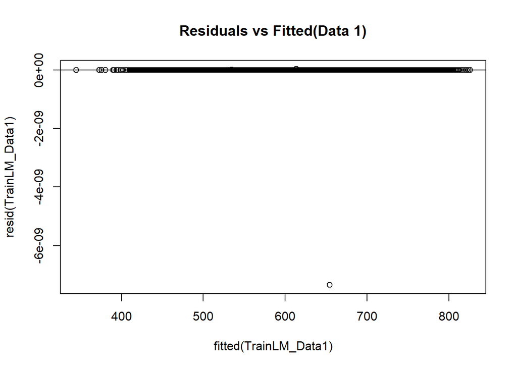

```r
# Fit linear model on each dataset
TrainLM_Data1 <- lm(y~.-error,TrainData_1)
TrainLM_Data2 <- lm(y~.-error,TrainData_2)
TrainLM_Data3 <- lm(y~.-error,TrainData_3)
TrainLM_Data4 <- lm(y~.-error,TrainData_4)
TrainLM_Data5 <- lm(y~.-error,TrainData_5)
TrainLM_Data6 <- lm(y~.-error,TrainData_6)
TrainLM_Data7 <- lm(y~.-error,TrainData_7)
TrainLM_Data8 <- lm(y~.-error,TrainData_8)

#....................................................................
## Residuals vs fitted plot to checkassumption of residuals homoscedasticity
## Normal Q-Q plot to check assumptions of residuals randomness,homoscedasticity
plot(fitted(TrainLM_Data1),resid(TrainLM_Data1),
     main = "Residuals vs Fitted(Data 1)")
abline(0,0)
```

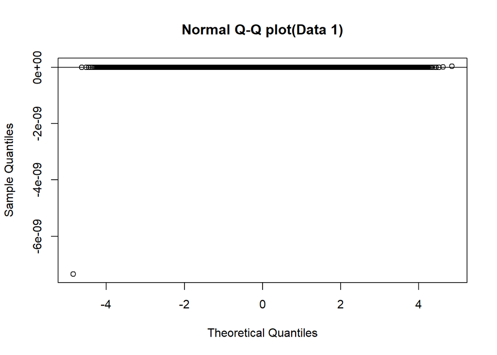

```r
qqnorm(resid(TrainLM_Data1),
       main="Normal Q-Q plot(Data 1)")
qqline(resid(TrainLM_Data1))
```

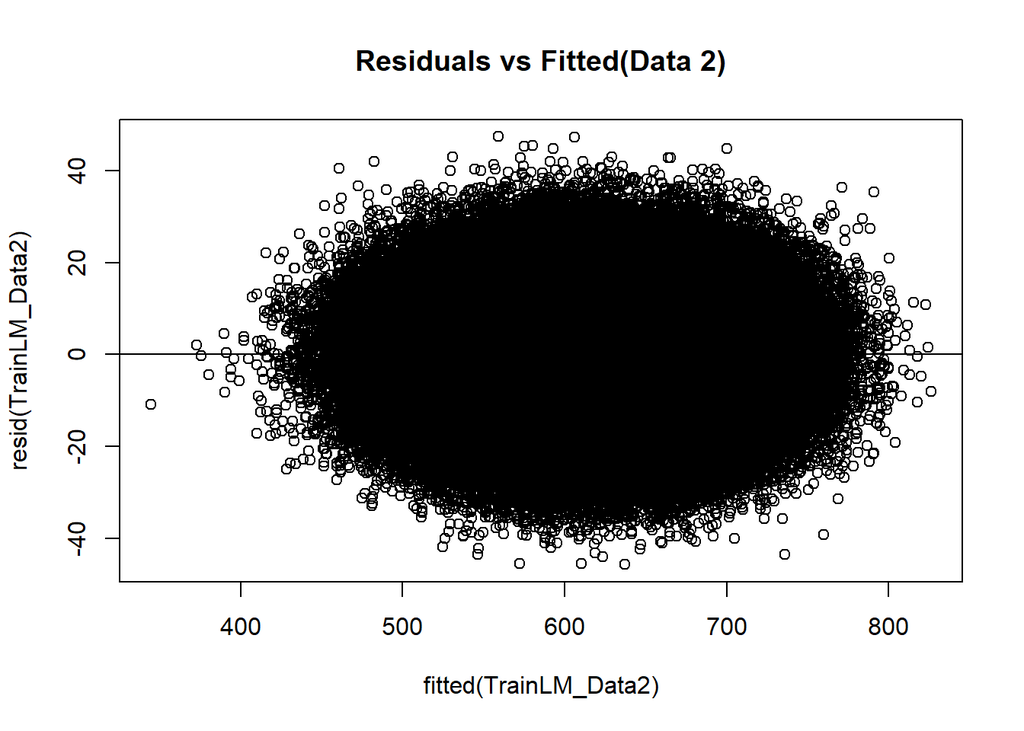

```r
plot(fitted(TrainLM_Data2),resid(TrainLM_Data2),
     main = "Residuals vs Fitted(Data 2)")
abline(0,0)
```

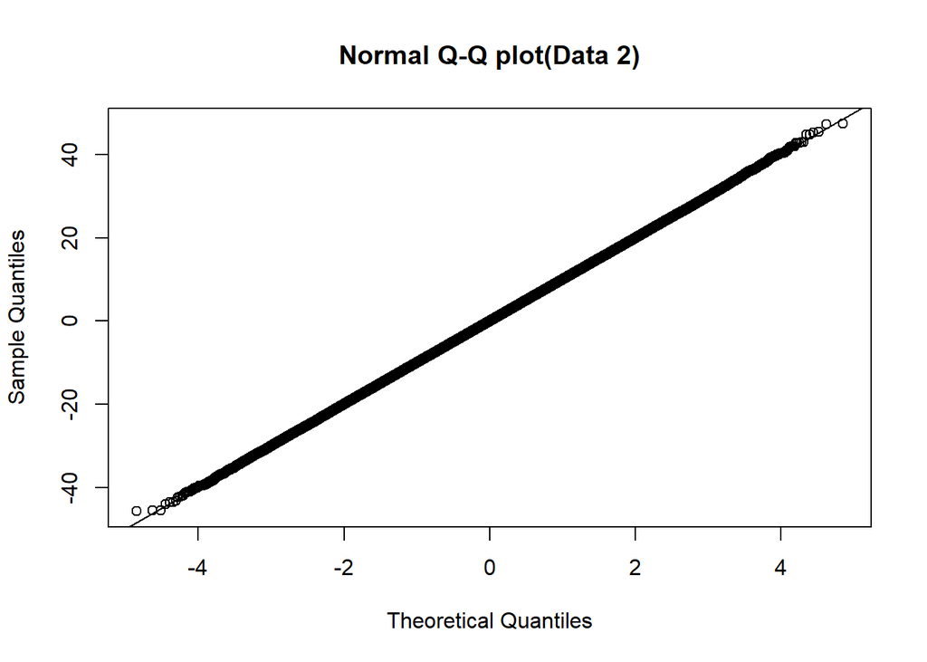

```r
qqnorm(resid(TrainLM_Data2),
       main = "Normal Q-Q plot(Data 2)")
qqline(resid(TrainLM_Data2))
```

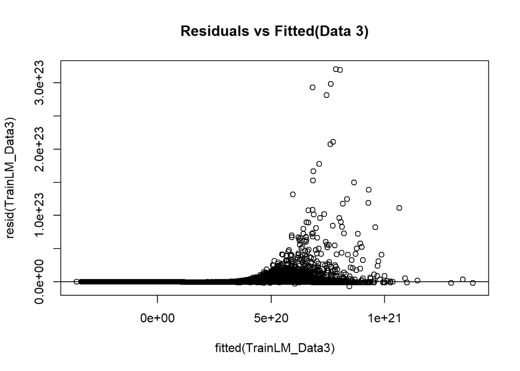

```r
plot(fitted(TrainLM_Data3),resid(TrainLM_Data3),
     main = "Residuals vs Fitted(Data 3)")
abline(0,0)
```

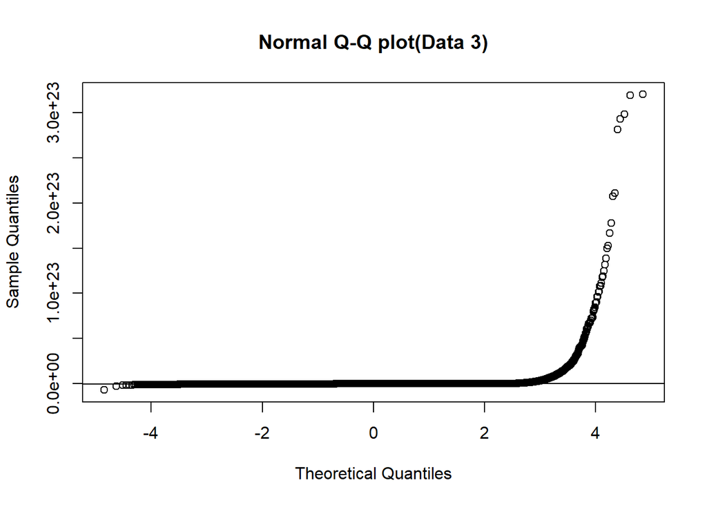

```r
qqnorm(resid(TrainLM_Data3),
       main="Normal Q-Q plot(Data 3)")
qqline(resid(TrainLM_Data3))
```

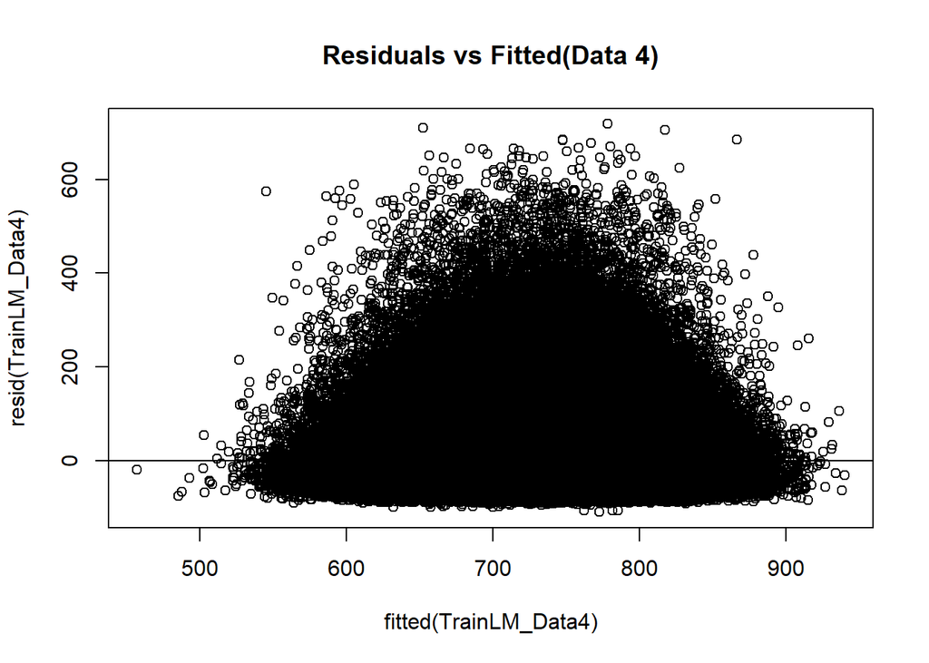

```r
plot(fitted(TrainLM_Data4),resid(TrainLM_Data4),
     main = "Residuals vs Fitted(Data 4)")
abline(0,0)
```

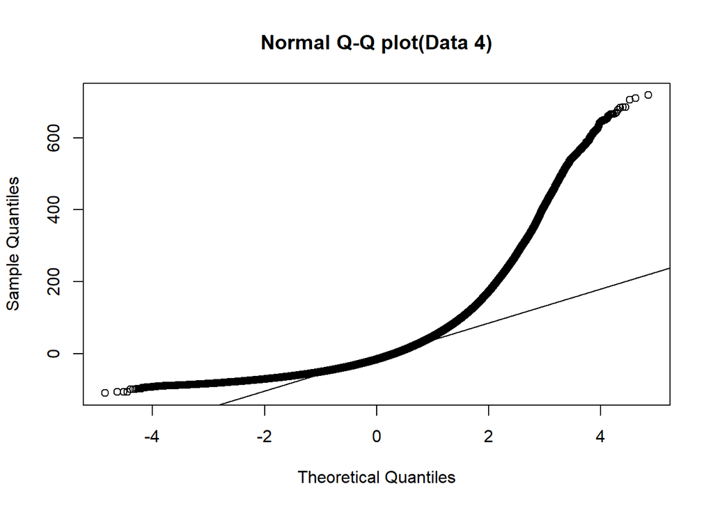

```r
qqnorm(resid(TrainLM_Data4),
       main="Normal Q-Q plot(Data 4)")
qqline(resid(TrainLM_Data4))
```

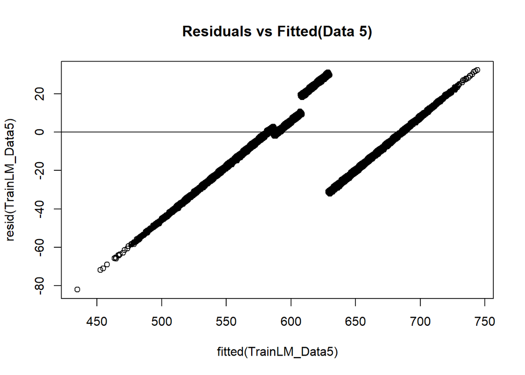

```r
plot(fitted(TrainLM_Data5),resid(TrainLM_Data5),
     main = "Residuals vs Fitted(Data 5)")
abline(0,0)
```

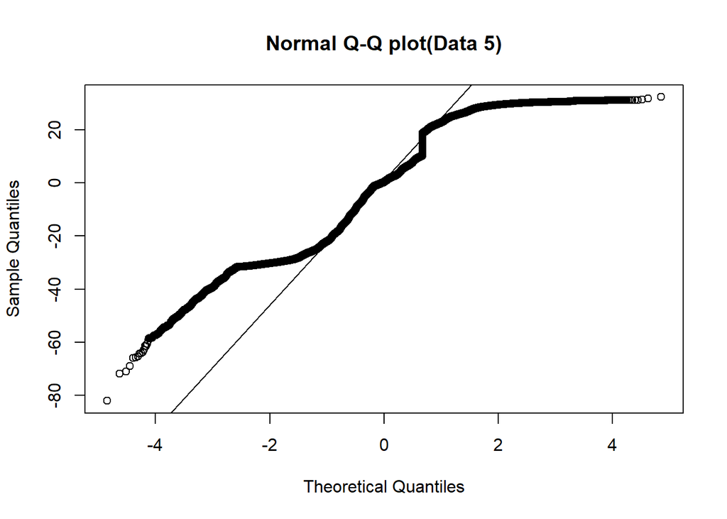

```r
qqnorm(resid(TrainLM_Data5),
       main="Normal Q-Q plot(Data 5)")
qqline(resid(TrainLM_Data5))
```

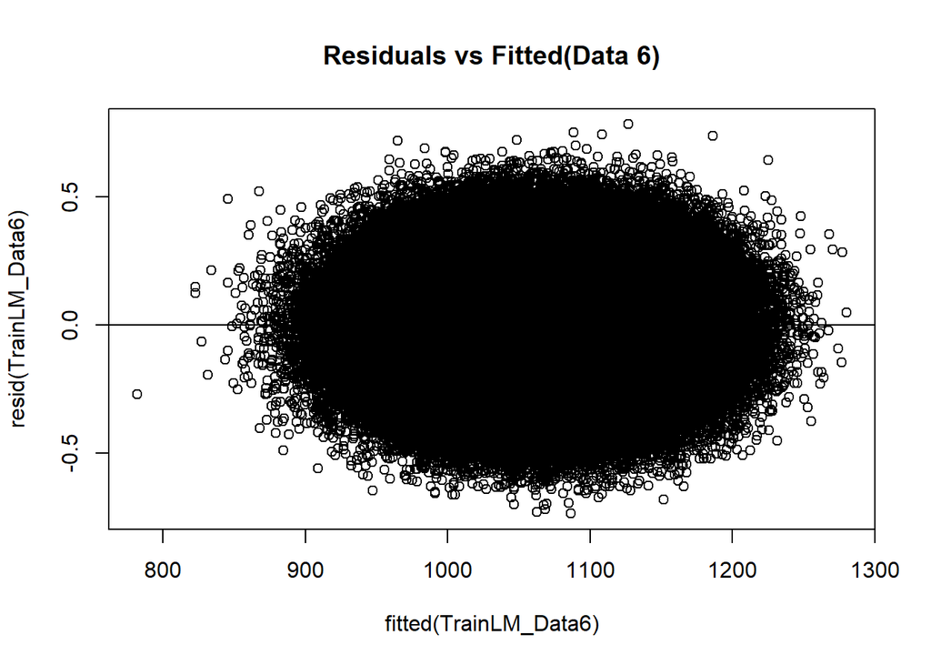

```r
plot(fitted(TrainLM_Data6),resid(TrainLM_Data6),
     main = "Residuals vs Fitted(Data 6)")
abline(0,0)
```

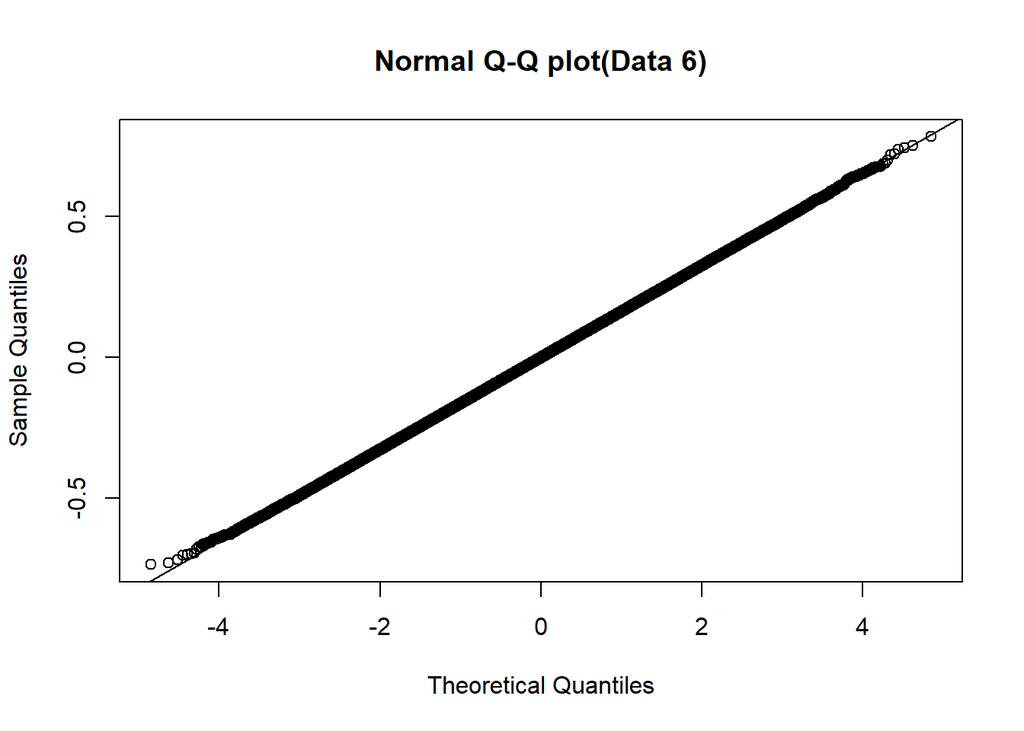

```r
qqnorm(resid(TrainLM_Data6),
       main="Normal Q-Q plot(Data 6)")
qqline(resid(TrainLM_Data6))
```

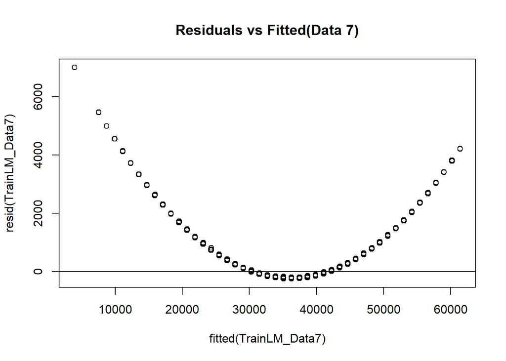

```r
plot(fitted(TrainLM_Data7),resid(TrainLM_Data7),
     main = "Residuals vs Fitted(Data 7)")
abline(0,0)
```

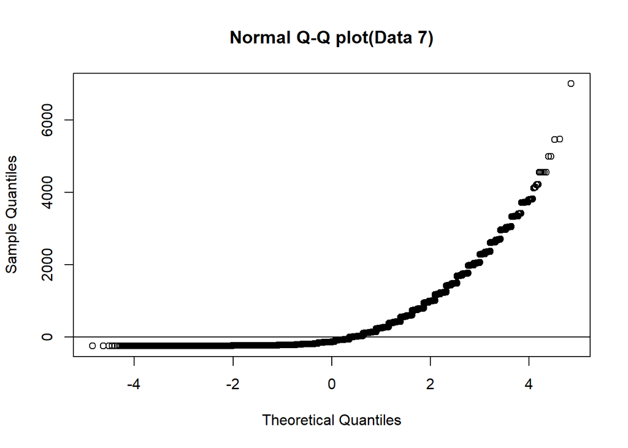

```r
qqnorm(resid(TrainLM_Data7),
       main="Normal Q-Q plot(Data 7)")
qqline(resid(TrainLM_Data1))
```

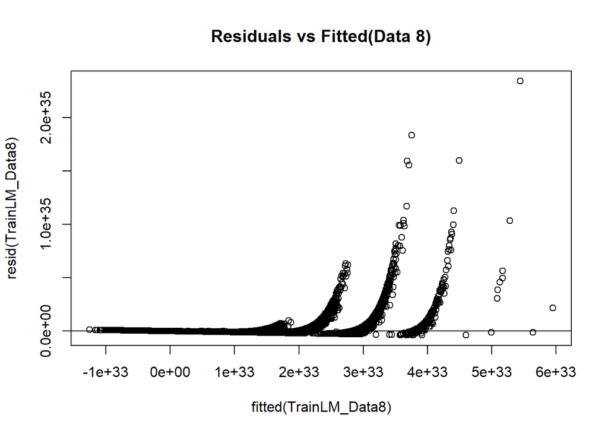

```r
plot(fitted(TrainLM_Data8),resid(TrainLM_Data8),
     main = "Residuals vs Fitted(Data 8)")
abline(0,0)
```

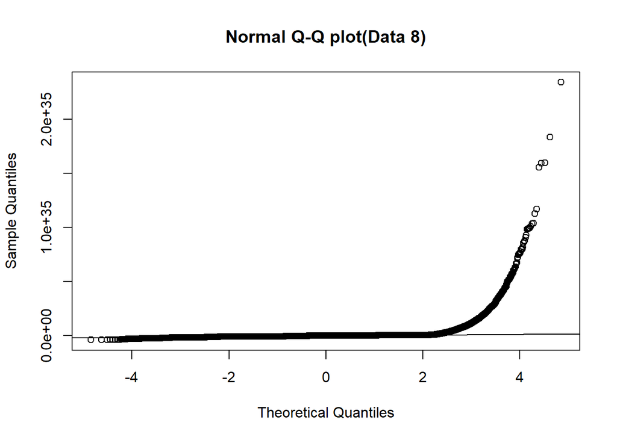

```r
qqnorm(resid(TrainLM_Data8),
       main="Normal Q-Q plot(Data 8)")
qqline(resid(TrainLM_Data8))
```

## Bootstrapped Linear Model

**Function for computing bootstraped linear model coefficient estimates and their 95% CI, Test/Train R-squared,MSE**

```r
boot_coef_estimates <- function(data,times,testdata){
  coeff <- data.frame(matrix(,nrow = ncol(data)-1,ncol=times))
  coeff_CI_lower <- data.frame(matrix(,nrow = ncol(data)-1,ncol=times))
  coeff_CI_upper <- data.frame(matrix(,nrow = ncol(data)-1,ncol=times))
  y_predicted_train    <- matrix(,nrow=nrow(data),ncol = 1)
  y_predicted_test    <- matrix(,nrow=nrow(testdata),ncol = 1)
  Train_r.squared <- 0
  Test_r.squared <- 0
  Train_MSE <- 0
  Test_MSE <- 0

  for (i in 1:times) {
  set.seed(i)
  sample <- sample(nrow(data),nrow(data)*0.80)
  model  <- lm(y~.-error,data[sample,])
  coeff[,i] <- data.frame(model$coefficients)
  coeff_CI_lower[,i] <- data.frame(confint(model,level = 0.95)[,1])
  coeff_CI_upper[,i] <- data.frame(confint(model,level = 0.95)[,2])
  }

Bootstrap_coefficients <- data.frame(boot_coefficients=rowMeans(coeff))
Bootstrap_coefficients_CI <- cbind(boot_lowerCI_coeff=rowMeans(coeff_CI_lower),
                                   boot_upperCI_coeff=rowMeans(coeff_CI_upper))

y_predicted_train[,1] <- Bootstrap_coefficients[1,1]+
  Bootstrap_coefficients[2,1]*data$x1+Bootstrap_coefficients[3,1]*data$x2+
  Bootstrap_coefficients[4,1]*data$x3+Bootstrap_coefficients[5,1]*data$x4+
  Bootstrap_coefficients[6,1]*data$x5+Bootstrap_coefficients[7,1]*data$x6

y_predicted_test[,1] <- Bootstrap_coefficients[1,1]+
  Bootstrap_coefficients[2,1]*testdata$x1+Bootstrap_coefficients[3,1]*testdata$x2+
  Bootstrap_coefficients[4,1]*testdata$x3+Bootstrap_coefficients[5,1]*testdata$x4+
  Bootstrap_coefficients[6,1]*testdata$x5+Bootstrap_coefficients[7,1]*testdata$x6

Train_r.squared <-
  sum((y_predicted_train-mean(data$y))^2)/sum((data$y-mean(data$y))^2)

Test_r.squared <-
  sum((y_predicted_test-mean(data$y))^2)/sum((testdata$y-mean(data$y))^2)

Train_MSE <- round(mean((y_predicted_train-testdata$y)^2),2)

Test_MSE <- round(mean((y_predicted_test-testdata$y)^2),2)

return(list(Bootstrap_coefficients = Bootstrap_coefficients,
            Bootstrap_coefficients_CI = Bootstrap_coefficients_CI,
            coeff_CI_lower = coeff_CI_lower,
            coeff_CI_upper = coeff_CI_upper,
            coeff = coeff,
            Train_R_squared = Train_r.squared,
            Test_R_squared = Test_r.squared,
            Train_MSE = Train_MSE,
            Test_MSE = Test_MSE))
}
```

# Appendix 4

## Linear Model Results

**Coefficient estimates and their 95% CI,Train/Test R-squared,MSE for each model on each train data**

```r
# Gather results
# Computing Coeficient estimates and 95% CI

## Coefficient estimates of each linear model
LM_coefficient_estimates <-
  data.frame(Coefficient=c("b0","b1","b2","b3","b4","b5","b6"),
             Actual=c(b0,b1,b2,b3,b4,b5,b6),
             Data1=round(TrainLM_Data1$coefficients,1),
             Data2=round(TrainLM_Data2$coefficients,1),
             Data3=round(TrainLM_Data3$coefficients,1),
             Data4=round(TrainLM_Data4$coefficients,1),
             Data5=round(TrainLM_Data5$coefficients,1),
             Data6=round(TrainLM_Data6$coefficients,1),
             Data7=round(TrainLM_Data7$coefficients,1),
             Data8=round(TrainLM_Data8$coefficients,1))

## 95% CI of coefficient estimates of each linear model
LM_coefficient_estimates_CI <-
  data.frame(Coefficient=c("b0","b1","b2","b3","b4","b5","b6"),
             Actual=c(b0,b1,b2,b3,b4,b5,b6),
             Data1_CI= paste("(",round(confint(TrainLM_Data1)[,1],1),",",
                                    round(confint(TrainLM_Data1)[,2],1),")"),
             Data2_CI= paste("(",round(confint(TrainLM_Data2)[,1],1),",",
                                    round(confint(TrainLM_Data2)[,2],1),")"),
             Data3_CI= paste("(",round(confint(TrainLM_Data3)[,1],1),",",
                                    round(confint(TrainLM_Data3)[,2],1),")"),
             Data4_CI= paste("(",round(confint(TrainLM_Data4)[,1],1),",",
                                    round(confint(TrainLM_Data4)[,2],1),")"),
             Data5_CI= paste("(",round(confint(TrainLM_Data5)[,1],1),",",
                                    round(confint(TrainLM_Data5)[,2],1),")"),
             Data6_CI= paste("(",round(confint(TrainLM_Data6)[,1],1),",",
                                    round(confint(TrainLM_Data6)[,2],1),")"),
             Data7_CI= paste("(",round(confint(TrainLM_Data7)[,1],1),",",
                                    round(confint(TrainLM_Data7)[,2],1),")"),
             Data8_CI= paste("(",round(confint(TrainLM_Data8)[,1],1),",",
                                    round(confint(TrainLM_Data8)[,2],1),")"))

#.............................................
# Computing Train/Test r-squared,MSE and creating a table containing these results

Predictions_TrainData_1 <- predict(TrainLM_Data1,TrainData_1)
Predictions_TrainData_2 <- predict(TrainLM_Data2,TrainData_2)
Predictions_TrainData_3 <- predict(TrainLM_Data3,TrainData_3)
Predictions_TrainData_4 <- predict(TrainLM_Data4,TrainData_4)
Predictions_TrainData_5 <- predict(TrainLM_Data5,TrainData_5)
Predictions_TrainData_6 <- predict(TrainLM_Data6,TrainData_6)
Predictions_TrainData_7 <- predict(TrainLM_Data6,TrainData_7)
Predictions_TrainData_8 <- predict(TrainLM_Data6,TrainData_8)

Predictions_TestData_1 <- predict(TrainLM_Data1,TestData_1)
Predictions_TestData_2 <- predict(TrainLM_Data2,TestData_2)
Predictions_TestData_3 <- predict(TrainLM_Data3,TestData_3)
Predictions_TestData_4 <- predict(TrainLM_Data4,TestData_4)
Predictions_TestData_5 <- predict(TrainLM_Data5,TestData_5)
Predictions_TestData_6 <- predict(TrainLM_Data6,TestData_6)
Predictions_TestData_7 <- predict(TrainLM_Data6,TestData_7)
Predictions_TestData_8 <- predict(TrainLM_Data6,TestData_8)

## R-squared of Train datasets
LM_R_squared_Train <-
  data.frame(LM_Train_R_squared=c(
    paste(round(summary(TrainLM_Data1)$r.squared*100,2),"%"),
    paste(round(summary(TrainLM_Data2)$r.squared*100,2),"%"),
    paste(round(summary(TrainLM_Data3)$r.squared*100,2),"%"),
    paste(round(summary(TrainLM_Data4)$r.squared*100,2),"%"),
    paste(round(summary(TrainLM_Data5)$r.squared*100,2),"%"),
    paste(round(summary(TrainLM_Data6)$r.squared*100,2),"%"),
    paste(round(summary(TrainLM_Data7)$r.squared*100,2),"%"),
    paste(round(summary(TrainLM_Data8)$r.squared*100,2),"%")))

## R-squared of Test datasets
LM_R_squared_Test <- data.frame(
LM_Test_R_squared=c(
paste(round((sum((Predictions_TestData_1-mean(TestData_1$y))^2)/
            (sum((TestData_1$y-mean(TestData_1$y))^2)))*100,2),"%"),
paste(round((sum((Predictions_TestData_2-mean(TestData_2$y))^2)/
            (sum((TestData_2$y-mean(TestData_2$y))^2)))*100,2),"%"),
paste(round((sum((Predictions_TestData_3-mean(TestData_3$y))^2)/
            (sum((TestData_3$y-mean(TestData_3$y))^2)))*100,2),"%"),
paste(round((sum((Predictions_TestData_4-mean(TestData_4$y))^2)/
            (sum((TestData_4$y-mean(TestData_4$y))^2)))*100,2),"%"),
paste(round((sum((Predictions_TestData_5-mean(TestData_5$y))^2)/
            (sum((TestData_5$y-mean(TestData_5$y))^2)))*100,2),"%"),
paste(round((sum((Predictions_TestData_6-mean(TestData_6$y))^2)/
            (sum((TestData_6$y-mean(TestData_6$y))^2)))*100,2),"%"),
paste(round((sum((Predictions_TestData_7-mean(TestData_7$y))^2)/
            (sum((TestData_7$y-mean(TestData_7$y))^2)))*100,2),"%"),
paste(round((sum((Predictions_TestData_8-mean(TestData_8$y))^2)/
            (sum((TestData_8$y-mean(TestData_8$y))^2)))*100,2),"%")))

## Combining results for train and test R-squared
LM_R_squared <- cbind(LM_R_squared_Train,LM_R_squared_Test)

## Combining results for train and test MSE
LM_MSE <- data.frame(
  LM_Train_MSE=c(
    round(mean((Predictions_TrainData_1-TrainData_1$y)^2),3),
    round(mean((Predictions_TrainData_2-TrainData_2$y)^2),3),
    round(mean((Predictions_TrainData_3-TrainData_3$y)^2),3),
    round(mean((Predictions_TrainData_4-TrainData_4$y)^2),3),
    round(mean((Predictions_TrainData_5-TrainData_5$y)^2),3),
    round(mean((Predictions_TrainData_6-TrainData_6$y)^2),3),
    round(mean((Predictions_TrainData_7-TrainData_7$y)^2),3),
    round(mean((Predictions_TrainData_8-TrainData_8$y)^2),3)),
  LM_Test_MSE=c(
    round(mean((Predictions_TestData_1-TestData_1$y)^2),3),
    round(mean((Predictions_TestData_2-TestData_2$y)^2),3),
    round(mean((Predictions_TestData_3-TestData_3$y)^2),3),
    round(mean((Predictions_TestData_4-TestData_4$y)^2),3),
    round(mean((Predictions_TestData_5-TestData_5$y)^2),3),
    round(mean((Predictions_TestData_6-TestData_6$y)^2),3),
    round(mean((Predictions_TestData_7-TestData_7$y)^2),3),
    round(mean((Predictions_TestData_8-TestData_8$y)^2),3)))

#............................................................................
# Create seperate tables displaying coefficient estimates,
# their 95% CI and Test/Train r-squared,MSE

Table_1 <- kable(LM_coefficient_estimates,
                 caption = "Table 1: Linear Model coefficients") %>%
kable_styling()

Table_2 <- kable(LM_coefficient_estimates_CI,
                 caption = "Table 2: Linear Model coefficients 95% CI") %>%
kable_styling()

Table_3 <- kable(cbind(Dataset=c(1,2,3,4,5,6,7,8),LM_R_squared,LM_MSE),
                 caption =
          "Table 3: Train/Test R-squared, Train/Test MSE of each regression model
           fitted on each Training set")%>%
kable_styling()
```

## Bootstrapped results

**Boostrapped coefficient estimates and 95% CI,Test/Train R-squared,MSE of model fitted on each train dataset**

```r
# Call function to get bootstrapping results for each Test dataset
boot_data1 <- boot_coef_estimates(TrainData_1,boot_samples,TestData_1)
boot_data2 <- boot_coef_estimates(TrainData_2,boot_samples,TestData_2)
boot_data3 <- boot_coef_estimates(TrainData_3,boot_samples,TestData_3)
boot_data4 <- boot_coef_estimates(TrainData_4,boot_samples,TestData_4)
boot_data5 <- boot_coef_estimates(TrainData_5,boot_samples,TestData_5)
boot_data6 <- boot_coef_estimates(TrainData_6,boot_samples,TestData_6)
boot_data7 <- boot_coef_estimates(TrainData_7,boot_samples,TestData_7)
boot_data8 <- boot_coef_estimates(TrainData_8,boot_samples,TestData_8)

#............................................................................
# Gather results

## Bootstrapped coefficient estimates of each model
Boot_coefficient_estimates <-
  data.frame(Coefficient=c("b0","b1","b2","b3","b4","b5","b6"),
             Actual=c(b0,b1,b2,b3,b4,b5,b6),
             Data1=round(boot_data1$Bootstrap_coefficients[,1],1),
             Data2=round(boot_data2$Bootstrap_coefficients[,1],1),
             Data3=round(boot_data3$Bootstrap_coefficients[,1],1),
             Data4=round(boot_data4$Bootstrap_coefficients[,1],1),
             Data5=round(boot_data5$Bootstrap_coefficients[,1],1),
             Data6=round(boot_data6$Bootstrap_coefficients[,1],1),
             Data7=round(boot_data7$Bootstrap_coefficients[,1],1),
             Data8=paste(round(boot_data8$Bootstrap_coefficients[,1],1)))

## Bootstrapped 95% CI of coefficient estimates of each model
Boot_coefficient_estimates_CI <- data.frame(
  Coefficient=c("b0","b1","b2","b3","b4","b5","b6"),
  Actual=c(b0,b1,b2,b3,b4,b5,b6),
  Data1_CI=paste("(",round(boot_data1$Bootstrap_coefficients_CI[,1],1),",",
                     round(boot_data1$Bootstrap_coefficients_CI[,2],1),")"),
  Data2_CI=paste("(",round(boot_data2$Bootstrap_coefficients_CI[,1],1),",",
                     round(boot_data2$Bootstrap_coefficients_CI[,2],1),")"),
  Data3_CI=paste("(",round(boot_data3$Bootstrap_coefficients_CI[,1],1),",",
                     round(boot_data3$Bootstrap_coefficients_CI[,2],1),")"),
  Data4_CI=paste("(",round(boot_data4$Bootstrap_coefficients_CI[,1],1),",",
                     round(boot_data4$Bootstrap_coefficients_CI[,2],1),")"),
  Data5_CI=paste("(",round(boot_data5$Bootstrap_coefficients_CI[,1],1),",",
                     round(boot_data5$Bootstrap_coefficients_CI[,2],1),")"),
  Data6_CI=paste("(",round(boot_data6$Bootstrap_coefficients_CI[,1],1),",",
                     round(boot_data6$Bootstrap_coefficients_CI[,2],1),")"),
  Data7_CI=paste("(",round(boot_data7$Bootstrap_coefficients_CI[,1],1),",",
                     round(boot_data7$Bootstrap_coefficients_CI[,2],1),")"),
  Data8_CI=paste("(",round(boot_data8$Bootstrap_coefficients_CI[,1],1),",",
                     round(boot_data8$Bootstrap_coefficients_CI[,2],1),")"))

## R-squared (linear model for each Train set has bootstrapped estimates)
Boot_R_squared <-
  data.frame(
    Boot_Train_R_squared =c(
      paste(round(boot_data1$Train_R_squared*100,2),"%"),
      paste(round(boot_data2$Train_R_squared*100,2),"%"),
      paste(round(boot_data3$Train_R_squared*100,2),"%"),
      paste(round(boot_data4$Train_R_squared*100,2),"%"),
      paste(round(boot_data5$Train_R_squared*100,2),"%"),
      paste(round(boot_data6$Train_R_squared*100,2),"%"),
      paste(round(boot_data7$Train_R_squared*100,2),"%"),
      paste(round(boot_data8$Train_R_squared*100,2),"%")),
Boot_Test_R_squared =c(
      paste(round(boot_data1$Test_R_squared*100,2),"%"),
      paste(round(boot_data2$Test_R_squared*100,2),"%"),
      paste(round(boot_data3$Test_R_squared*100,2),"%"),
      paste(round(boot_data4$Test_R_squared*100,2),"%"),
      paste(round(boot_data5$Test_R_squared*100,2),"%"),
      paste(round(boot_data6$Test_R_squared*100,2),"%"),
      paste(round(boot_data7$Test_R_squared*100,2),"%"),
      paste(round(boot_data8$Test_R_squared*100,2),"%")))

## MSE(linear model for each Train set has bootstrapped estimates)
Boot_MSE <-
  data.frame(
    Boot_Train_MSE=c(round(boot_data1$Train_MSE,2),
                     round(boot_data2$Train_MSE,2),
                     round(boot_data3$Train_MSE,2),
                     round(boot_data4$Train_MSE,2),
                     round(boot_data5$Train_MSE,2),
                     round(boot_data6$Train_MSE,2),
                     round(boot_data7$Train_MSE,2),
                     round(boot_data8$Train_MSE,2)),
     Boot_Test_MSE=c(round(boot_data1$Test_MSE,2),
                     round(boot_data2$Test_MSE,2),
                     round(boot_data3$Test_MSE,2),
                     round(boot_data4$Test_MSE,2),
                     round(boot_data5$Test_MSE,2),
                     round(boot_data6$Test_MSE,2),
                     round(boot_data7$Test_MSE,2),
                     round(boot_data8$Test_MSE,2)))

#..........................................................................
# Create seperate tables displaying coefficient estimates,
# their 95% CI and Test/Train r-squared,MSE

Table_4 <- kable(
  cbind(coefficients=c("(intercept)","x1","x2","x3","x4","x5","x6"),
        Boot_coefficient_estimates),
        caption = "Table 4: Boostrap coefficient Estimates")%>%
kable_styling()

Table_5 <- kable(
  cbind(coefficients=c("(intercept)","x1","x2","x3","x4","x5","x6"),
        Boot_coefficient_estimates_CI),
        caption = "Table 5: Boostrap coeffficient Estimates 95% CI")%>%
kable_styling()

Table_6 <- kable(cbind(Data=c(1:8),Boot_R_squared,Boot_MSE),
                 caption = "Table 6: Train/Test R squared and Train/Test
                 MSE of each regression model with bootstrapped coefficients
                 fitted on each Training set")%>%
kable_styling()
```

## Displaying Results

**Linear Model & Bootstraped Linear Model results**

```r
Table_1
```

Table 1: Linear Model coefficients

|  | Coefficient | Actual | Data1 | Data2 | Data3 | Data4 | Data5 | Data6 | Data7 | Data8 |
| --- | --- | --- | --- | --- | --- | --- | --- | --- | --- | --- |
| (Intercept) | b0 | 4.0 | 4.0 | 3.9 | -6.284195e+20 | 114.6 | 215.3 | -25.6 | -35640.3 | -4.055928e+33 |
| x1 | b1 | 2.0 | 2.0 | 2.0 | 5.214340e+19 | 2.0 | 1.4 | 2.0 | 4.0 | 3.143867e+32 |
| x2 | b2 | 10.0 | 10.0 | 10.0 | 4.956582e+18 | 10.0 | 6.4 | 10.0 | 1198.0 | 3.104339e+31 |
| x3 | b3 | 3.0 | 3.0 | 3.0 | 3.085243e+20 | 3.1 | 2.0 | 3.0 | 2.9 | 1.019710e+33 |
| x4 | b4 | 7.0 | 7.0 | 7.0 | 1.786939e+20 | 7.0 | 4.8 | 7.3 | 14.6 | 2.595147e+31 |
| x5 | b5 | 0.1 | 0.1 | 0.1 | 5.567971e+18 | 0.1 | 0.1 | 0.4 | -0.2 | -4.006420e+30 |
| x6 | b6 | 1.0 | 1.0 | 1.0 | 3.410499e+19 | 1.1 | 0.8 | 1.3 | 1.5 | 1.021009e+31 |

```r
Table_4
```

Table 4: Boostrap coefficient Estimates

| coefficients | Coefficient | Actual | Data1 | Data2 | Data3 | Data4 | Data5 | Data6 | Data7 | Data8 |
| --- | --- | --- | --- | --- | --- | --- | --- | --- | --- | --- |
| (intercept) | b0 | 4.0 | 4.0 | 3.9 | -6.277239e+20 | 114.6 | 215.3 | -25.6 | -35640.3 | -4.05239634237267e+33 |
| x1 | b1 | 2.0 | 2.0 | 2.0 | 5.206149e+19 | 2.0 | 1.4 | 2.0 | 4.0 | 3.14295853496721e+32 |
| x2 | b2 | 10.0 | 10.0 | 10.0 | 4.949472e+18 | 10.0 | 6.4 | 10.0 | 1198.0 | 3.10389494122834e+31 |
| x3 | b3 | 3.0 | 3.0 | 3.0 | 3.082222e+20 | 3.1 | 2.0 | 3.0 | 2.9 | 1.01946352382037e+33 |
| x4 | b4 | 7.0 | 7.0 | 7.0 | 1.785143e+20 | 6.9 | 4.8 | 7.3 | 14.6 | 2.59578520820815e+31 |
| x5 | b5 | 0.1 | 0.1 | 0.1 | 5.577557e+18 | 0.1 | 0.1 | 0.4 | -0.2 | -3.96969035783599e+30 |
| x6 | b6 | 1.0 | 1.0 | 1.0 | 3.409323e+19 | 1.1 | 0.8 | 1.3 | 1.5 | 1.01294771602935e+31 |

```r
Table_2
```

Table 2: Linear Model coefficients 95% CI

| Coefficient | Actual | Data1_CI | Data2_CI | Data3_CI | Data4_CI | Data5_CI | Data6_CI | Data7_CI | Data8_CI |
| --- | --- | --- | --- | --- | --- | --- | --- | --- | --- |
| b0 | 4.0 | ( 4 , 4 ) | ( 3.6 , 4.2 ) | ( -6.62771080929686e+20 , -5.94067859983293e+20 ) | ( 112.8 , 116.4 ) | ( 214.8 , 215.8 ) | ( -25.7 , -25.6 ) | ( -35649.8 , -35630.8 ) | ( -4.25851330540637e+33 , -3.85334210109431e+33 ) |
| b1 | 2.0 | ( 2 , 2 ) | ( 2 , 2 ) | ( 4.6826599603032e+19 , 57460192636333686784 ) | ( 1.7 , 2.3 ) | ( 1.3 , 1.5 ) | ( 2 , 2 ) | ( 2.5 , 5.4 ) | ( 3.08827217889352e+32 , 3.19946211769967e+32 ) |
| b2 | 10.0 | ( 10 , 10 ) | ( 10 , 10 ) | ( 4413618736443949568 , 5499545189575669760 ) | ( 10 , 10.1 ) | ( 6.4 , 6.4 ) | ( 10 , 10 ) | ( 1197.8 , 1198.1 ) | ( 3.04756424524109e+31 , 3.16111375679352e+31 ) |
| b3 | 3.0 | ( 3 , 3 ) | ( 2.9 , 3 ) | ( 2.99633891908995e+20 , 3.17414785377075e+20 ) | ( 2.6 , 3.6 ) | ( 1.9 , 2.1 ) | ( 3 , 3 ) | ( 0.5 , 5.4 ) | ( 1.01463762885845e+33 , 1.02478256695858e+33 ) |
| b4 | 7.0 | ( 7 , 7 ) | ( 6.9 , 7 ) | ( 1.72958239039282e+20 , 1.84429548455682e+20 ) | ( 6.7 , 7.3 ) | ( 4.7 , 4.9 ) | ( 7.3 , 7.3 ) | ( 13 , 16.2 ) | ( 2.07853682292172e+31 , 3.1117573645545e+31 ) |
| b5 | 0.1 | ( 0.1 , 0.1 ) | ( 0.1 , 0.1 ) | ( 4237888108810826752 , 6898053344386358272 ) | ( 0.1 , 0.2 ) | ( 0.1 , 0.1 ) | ( 0.4 , 0.4 ) | ( -0.5 , 0.2 ) | ( -9.17693217723412e+30 , 1.16409130778858e+30 ) |
| b6 | 1.0 | ( 1 , 1 ) | ( 0.9 , 1 ) | ( 3.1449173373269e+19 , 36760797205623214080 ) | ( 0.9 , 1.4 ) | ( 0.7 , 0.8 ) | ( 1.3 , 1.3 ) | ( 0.2 , 2.9 ) | ( 5.03663568325237e+30 , 1.53835348067652e+31 ) |

```r
Table_5
```

Table 5: Boostrap coeffficient Estimates 95% CI

| coefficients | Coefficient | Actual | Data1_CI | Data2_CI | Data3_CI | Data4_CI | Data5_CI | Data6_CI | Data7_CI | Data8_CI |
| --- | --- | --- | --- | --- | --- | --- | --- | --- | --- | --- |
| (intercept) | b0 | 4.0 | ( 4 , 4 ) | ( 3.6 , 4.2 ) | ( -6.66034352112821e+20 , -5.89413360521726e+20 ) | ( 112.6 , 116.6 ) | ( 214.7 , 215.9 ) | ( -25.7 , -25.6 ) | ( -35651 , -35629.7 ) | ( -4.2785971360799e+33 , -3.82619554866545e+33 ) |
| x1 | b1 | 2.0 | ( 2 , 2 ) | ( 1.9 , 2 ) | ( 46131959032641069056 , 57991017201071136778 ) | ( 1.7 , 2.3 ) | ( 1.3 , 1.5 ) | ( 2 , 2 ) | ( 2.3 , 5.6 ) | ( 3.08088162886146e+32 , 3.20503544107295e+32 ) |
| x2 | b2 | 10.0 | ( 10 , 10 ) | ( 10 , 10 ) | ( 4343941075803473408 , 5555002009090231296 ) | ( 10 , 10.1 ) | ( 6.4 , 6.4 ) | ( 10 , 10 ) | ( 1197.8 , 1198.1 ) | ( 3.04050145498392e+31 , 3.16728842747275e+31 ) |
| x3 | b3 | 3.0 | ( 3 , 3 ) | ( 2.9 , 3 ) | ( 2.98307086297684e+20 , 3.1813736083289e+20 ) | ( 2.6 , 3.6 ) | ( 1.9 , 2.2 ) | ( 3 , 3 ) | ( 0.2 , 5.7 ) | ( 1.01379976272402e+33 , 1.02512728491672e+33 ) |
| x4 | b4 | 7.0 | ( 7 , 7 ) | ( 6.9 , 7 ) | ( 1.72117613718759e+20 , 1.84911030618191e+20 ) | ( 6.6 , 7.3 ) | ( 4.7 , 4.9 ) | ( 7.3 , 7.3 ) | ( 12.8 , 16.4 ) | ( 2.01893556922969e+31 , 3.1726348471866e+31 ) |
| x5 | b5 | 0.1 | ( 0.1 , 0.1 ) | ( 0.1 , 0.1 ) | ( 4094188852043617792 , 7060924619397346304 ) | ( 0.1 , 0.2 ) | ( 0.1 , 0.1 ) | ( 0.4 , 0.4 ) | ( -0.6 , 0.2 ) | ( -9.74300205279551e+30 , 1.80362133712353e+30 ) |
| x6 | b6 | 1.0 | ( 1 , 1 ) | ( 0.9 , 1 ) | ( 31131431288702898176 , 37055032477988323328 ) | ( 0.8 , 1.4 ) | ( 0.7 , 0.8 ) | ( 1.3 , 1.3 ) | ( 0 , 3 ) | ( 4.35272058568567e+30 , 1.59062337349013e+31 ) |

```r
Table_3
```

Table 3: Train/Test R-squared, Train/Test MSE of each regression model fitted on each Training set

| Dataset | LM_Train_R_squared | LM_Test_R_squared | LM_Train_MSE | LM_Test_MSE |
| --- | --- | --- | --- | --- |
| 1 | 100 % | 100 % | 0.000000e+00 | 0.000000e+00 |
| 2 | 96.02 % | 96.11 % | 9.984100e+01 | 1.000310e+02 |
| 3 | 1.2 % | 0.96 % | 1.470127e+42 | 1.862066e+42 |
| 4 | 37.98 % | 38.39 % | 3.963112e+03 | 3.945431e+03 |
| 5 | 75.24 % | 75.43 % | 3.271680e+02 | 3.272150e+02 |
| 6 | 100 % | 100 % | 2.700000e-02 | 2.700000e-02 |
| 7 | 99.67 % | 3690.47 % | 1.306172e+09 | 1.308316e+09 |
| 8 | 18.33 % | 1.96 % | 2.007499e+66 | 2.135398e+66 |

```r
Table_6
```

Table 6: Train/Test R squared and Train/Test MSE of each regression model with bootstrapped coefficients fitted on each Training set

| Data | Boot_Train_R_squared | Boot_Test_R_squared | Boot_Train_MSE | Boot_Test_MSE |
| --- | --- | --- | --- | --- |
| 1 | 100 % | 100 % | 4.814830e+03 | 0.000000e+00 |
| 2 | 96.02 % | 96.11 % | 4.916650e+03 | 1.000300e+02 |
| 3 | 1.2 % | 0.96 % | 1.901091e+42 | 1.862069e+42 |
| 4 | 37.98 % | 38.39 % | 8.747380e+03 | 3.945430e+03 |
| 5 | 75.24 % | 75.43 % | 2.308690e+03 | 3.272200e+02 |
| 6 | 100 % | 100 % | 4.963080e+03 | 3.000000e-02 |
| 7 | 99.67 % | 99.56 % | 6.887960e+07 | 1.137896e+05 |
| 8 | 18.32 % | 17.37 % | 2.452908e+66 | 1.727354e+66 |